# MSBA Capstone - Home Credit

Shane Nisley, Aiden Coutin, Jacob Jarrard, Gustav Vøllo

05 November 2023

# I. Summary & Explanations

## Business Problem Statement

In the face of global financial disparities, Home Credit identified a critical need to extend credit services to the unbanked and underbanked populations—a demographic traditionally perceived as high-risk due to the absence of conventional credit histories. Our strategic response harnesses predictive analytics to refine our risk evaluation criteria, balancing risk with the imperative to offer fair credit access. This effort aligns with our corporate objective to shrink loan default rates while extending credit to those historically sidelined by the financial system.

Our latest data-driven model advances this agenda to an inflection point in our business processes. Building on extensive exploratory data analysis, after conducting a series of different machine learning algorithms, we applied a gradient boosting framework that utilizes identified predictive indicators to create a model that is likely the most accurate algorithm available to our team. The model’s efficacy, evidenced by its empirical foundation, demonstrates not only fidelity to statistical rigor but also to our mission of financial inclusivity.

The practical implications of deploying our predictive model are significant. We distilled over 356,000 client records into actionable intelligence, categorizing loan applicants with much precision. This capability promises to minimize default exposure and, critically, to dismantle barriers to credit for viable applicants devoid of traditional financial footprints. The model is a cornerstone in our strategy to achieve a sustainable default rate reduction, reflecting our concerted effort to engender economic resilience among emerging market demographics.

In presenting this model, we affirm our dedication to combining analytical excellence with a progressive credit provisioning philosophy. As we move forward, our focus remains on the dual objectives of diminishing financial vulnerability for the unbanked and underbanked and enhancing Home Credit’s role as an enabler of economic opportunity. Our commitment to this two-prong mandate is a blueprint for responsible expansion in the dynamic consumer finance landscape.

## Bottom Line:

Our team ultimately employed the XGBoost algorithm for its accuracy in predicting outcomes, given its effectiveness in handling large datasets and constructing advanced predictive models that sequentially learn from prior mistakes to improve performace. Our model proved its mettle by generating an accuracy of over .92 (difficult given the skewed target variable) and a Kaggle score above 0.76 (XGBoosted at 2000 rounds.) However, its success uncovers a real conversation about how we can minimize defaults and maximize loan approvals, and how many defaults Home Credit can ultimately afford.

Despite its accuracy, the model, without adjustments for the minority class weight, predicted defaults significantly less than the actual 8% default rate in our training data (true positives and false positives.) That is to say, no model we employed performed well out of the box when it came to the true positive rate, also known as sensitivity or recall. (Or one could argue that the true positives we identified are very likely to default!) This mismatch suggests that our pursuit of precision also needs to maximize a more correct representation of default cases to avoid excluding genuine borrowers or including probable defaults. In the end, all models pointed to a trade-off between model precision and the representation of minority class instances. Though difficult to solve, this knowledge powered our collective way forward and stands out as our mid-term objective to solve for this project.

Above all, our analysis pinpointed the critical variables within our dataset—and generated additional ones from supplementary data—that most accurately forecast whether a customer will default or repay a loan. Armed with this knowledge, we can prioritize collecting the most predictive data for loan processing moving forward in the application process and disregard customer information that offers no predictive value for loan outcomes.

## Data Cleaning & Preparation Process

Each member of the team set out to explore the data individually. Beyond exploratory data analysis, each member of the team identified and wrestled with slightly different variables within the data set. Some of us identified different opportunities to enhance our outcomes with individual feature selection and engineering. For the most part we collectively came to the same conclusion on which variables to include in our final model. The following data cleaning process reflects our team’s concensus:

Upon examining the target variable, we discovered a significant class imbalance; the majority class constituted approximately 92% of the data. This indicated potential challenges in model training, as models could be predisposed to favor the majority class, possibly impacting the predictive performance for the minority class.

We thoroughly analyzed the dataset for outliers, necessary transformations, and missing values, using the data dictionary provided by Home Credit to guide our understanding of the variables. We scrutinized individual variables, such as loan types (cash vs. revolving loans), and implemented the following cleaning actions:

- Transformed negative values to positives to correct skewness and distribution.
- Eliminated unrealistic outliers, such as employment days exceeding a typical human lifespan, substituting them with median values.
- Imposed a cap on total income at the 99th percentile, with additional caps applied judiciously based on realistic assessments.

Our focus then shifted to identifying zero and near-zero variance predictors, which are often uninformative for models. We eliminated predictors with minimal variance and substantial missing data. Subsequently, we engaged in feature engineering, creating new variables we hypothesized would enhance model performance. Feature importance was evaluated using Random Forest models, allowing us to discard non-contributory features. Notably, financial ratios emerged as significant predictors.

Imputation was our concluding step, deliberately postponed to address only the variables retained for our final model. Initially considering the MICE package for its real-world applicability, we encountered computational limitations. Consequently, we opted for simpler imputation methods. Variables with a near-normal distribution were imputed with the mean to preserve central tendency, while others were imputed with the median to mitigate the influence of extreme values. Finally, we analyzed the final dataset, ensuring maintenance of original spreads and distributions, variable importance, and completeness

## Group Modeling Process

In the development of our predictive models, our team evaluated a variety of algorithmic approaches. We initially considered five distinct models: linear regression, logistical regression, regression trees (using the ‘rpart’ package), Naïve Bayes, and a classification tree. In most cases we attempted to apply the same set of features across all models.

Our group utilized individual members’ EDA and independent data cleaning and pre-processing techniques for use in our experimental models. We ultimately converged on one data set for use in our final model (process documented in section II below.)

The performance evaluation metrics employed included Area Under the Curve (AUC), confusion matrices, and Kaggle competition scores. These metrics guided us to the model exhibiting the best predictive power. In an attempt to refine our models further, we experimented with feature selection, using the most predictive variables. At the end of the day, no other model yielded improved results over the use of the ‘clean8’ feature set (used in the final model below.)

Hyperparameter optimization was conducted specifically for the classification tree model. The focus of this optimization was to determine an optimal count of leaf nodes that balanced model complexity and predictive power, aiming to prevent overfitting. The results of this model were used in feature selection and feature engineering.

Collectively, our team employed upwards of six different machine learning algorithms. As noted, we focused on supervised learning algorithms that are considered “white box,” due to their interpretability, before finalizing our decision to use a gradient boosted model. Despite the individualized data cleansing approaches taken by each team member, some of which were omitted here for conciseness, the results varied, providing both unexpected insights and amusing anecdotes.

One of the main obstacles we faced was inconsistent computational resources. The large volume of data presented a significant challenge, particularly when attempting to deploy an Artificial Neural Network (ANN) model. To mitigate this, we considered scaling down the feature set to the most essential elements, but we were ultimately unable to proceed with ANN modeling due to the limitations of our computing power.

The following data frame shows our groups summary statsitics as we tried various models with different degrees of success:

Group Sample Models

| Model | True_Negatives | False_Positives | False_Negatives | True_Positives | Accuracy | Sensitivity | Specificity | AUC | Kaggle_Score |
| --- | --- | --- | --- | --- | --- | --- | --- | --- | --- |
| Linear Regression (Training) | 56544 | 4931 | 11 | 15 | 0.9196 | 0.999805 | 0.003033 | 0.7482 | 0.74 |
| Logistic Regression (Training) | 282642 | 24790 | 44 | 35 | 0.9192 | 0.99984 | 0.00141 | 0.7125945 | 0.7 |
| XGBoost model #1 (Training) | 282472 | 24304 | 214 | 521 | 0.9203 | 0.99924 | 0.02099 | 0.78 | 0.739 |
| XGBoost model #2 Weighted Minority (Training) | 200915 | 81771 | 7238 | 17587 | 0.7106 | 0.7107 | 0.7096 | 0.786 | 0.733 |

## Group Modeling Interpretations

Given our combined efforts and the consensus of the team, the singly most important element to improve our models was data processing, feature engineering, and imputing the appropriate values for missing data. In short, we had to make the best data possible. With less specific data pre-processing we achieved some measure of success with our various models, but we simply could not be confident in our final model until we agreed on how the data needed to be molded. This took an inordinate amount of collective time and learning along the way iteratively to have a model worth sharing. There are many black box methods that can overcome bad data to a degree, but they simply can not do as good as they should without deep domain knowledge and specific human insight skilfully manipulating the features variable related to each customer. There is no way, particularly at the current time, that generative AI or other automated ML assistance can do feature engineering like a human can, especially when the data is as unwieldy as that provided.

Second to EDA, pre-processing, and feature engineering, we all agreed that our attempts with Extreme Gradient Boosting was clearly the best choice, but we would not have been prepared to employ it without first drawing on the clear and helpful output of the “white box” methods, such as linear and logistical regression. We lament leaving a lot of work on the cutting room floor, but note that what follows proved to be our groups best effort.

# II. XGBOOST - Final Model Selection

## Exploring Target Variable Data

```r
# Libraries

if (!require("pacman")) install.packages("pacman")
pacman::p_load(tidyverse, skimr, GGally, plotly, viridis,
               caret, DT, data.table, lightgbm, readr, e1071, ranger,
               parallel, mice, corrplot, ggplot2, xgboost, pROC, knitr, kableExtra )

#Data
test_data <- read.csv("application_test.csv")
train_data <- read.csv("application_train.csv")
bureau <- read.csv("bureau.csv")
b_balance <- read.csv("bureau_balance.csv")
prev <- read.csv("previous_application.csv")
```

```r
## Show table of target variable
table(train_data$TARGET)
```

```
##
##      0      1
## 282686  24825
```

```r
## Majority Class
(majority_class <- which.max(table(train_data$TARGET)))
```

```
## 0
## 1
```

```r
## Baseline accuracy
(majorityPerc <- sum(train_data$TARGET == 0) / nrow(train_data))
```

```
## [1] 0.9192712
```

The data is unbalanced. We would achieve an accuracy of about 92% if we just assumed that nobody defaults on their loan.

## Informed EDA & Outlier Adjustment

```r
## summary of data

#summary(train_data)

# Cash loans and Revolving loans
table(train_data$NAME_CONTRACT_TYPE)
```

```
##
##      Cash loans Revolving loans
##          278232           29279
```

```r
## use skim to look over the data and get a feel for number of observations, range, and missing/ unique values
# train_data %>% skim() %>% kable() # Leave this out; can be included when required

# Remove columns that have less than 60% of their data

# Calculate the proportion of missing values for each column
missing_props <- map_dbl(train_data, ~mean(is.na(.)))

# Filter out columns with more than 60% missing values
clean1 <- train_data %>% select(which(missing_props <= 0.6))

# factoring categorical variables
clean2 <- clean1

clean2[] <- lapply(clean1, function(x)
  if (is.character(x)) factor(x) else x)

## Noticed the negative values for days, changing those rows to absolute values

# Identify columns with any negative values and create clean3
clean3 <- clean2 %>%
  mutate(
    DAYS_BIRTH = ifelse(DAYS_BIRTH < 0, abs(DAYS_BIRTH), DAYS_BIRTH),
    DAYS_EMPLOYED = ifelse(DAYS_EMPLOYED < 0, abs(DAYS_EMPLOYED), DAYS_EMPLOYED),
    DAYS_REGISTRATION = ifelse(DAYS_REGISTRATION < 0, abs(DAYS_REGISTRATION), DAYS_REGISTRATION),
    DAYS_ID_PUBLISH = ifelse(DAYS_ID_PUBLISH < 0, abs(DAYS_ID_PUBLISH), DAYS_ID_PUBLISH),
    DAYS_LAST_PHONE_CHANGE = ifelse(DAYS_LAST_PHONE_CHANGE < 0, abs(DAYS_LAST_PHONE_CHANGE), DAYS_LAST_PHONE_CHANGE))

# dealing with outliers

clean4 <- clean3 %>%

  # 1. Capping AMT_INCOME_TOTAL at the 99th percentile
  mutate(AMT_INCOME_TOTAL = ifelse(AMT_INCOME_TOTAL > quantile(AMT_INCOME_TOTAL, 0.99, na.rm = TRUE),
                                   quantile(AMT_INCOME_TOTAL, 0.99, na.rm = TRUE),
                                   AMT_INCOME_TOTAL)) %>%

  # 2. Replacing impossible DAYS_EMPLOYED value with the median
  mutate(DAYS_EMPLOYED = ifelse(DAYS_EMPLOYED == 365243,
                                median(DAYS_EMPLOYED[DAYS_EMPLOYED != 365243], na.rm = TRUE),
                                DAYS_EMPLOYED)) %>%

  # 3. Capping CNT_CHILDREN at 5
  mutate(CNT_CHILDREN = ifelse(CNT_CHILDREN > 5, 5, CNT_CHILDREN)) %>%

  # 4. Capping AMT_REQ_CREDIT_BUREAU_QRT at the 95th percentile
  mutate(AMT_REQ_CREDIT_BUREAU_QRT = ifelse(AMT_REQ_CREDIT_BUREAU_QRT > quantile(AMT_REQ_CREDIT_BUREAU_QRT, 0.95, na.rm = TRUE),
                                            quantile(AMT_REQ_CREDIT_BUREAU_QRT, 0.95, na.rm = TRUE),
                                            AMT_REQ_CREDIT_BUREAU_QRT)) %>%

  # 5. Capping REGION_POPULATION_RELATIVE at the 99th percentile
  mutate(REGION_POPULATION_RELATIVE = ifelse(REGION_POPULATION_RELATIVE > quantile(REGION_POPULATION_RELATIVE, 0.99, na.rm = TRUE),
                                             quantile(REGION_POPULATION_RELATIVE, 0.99, na.rm = TRUE),
                                             REGION_POPULATION_RELATIVE))
```

## Additional Data Cleaning and Analysis

```r
# Numeric columns from clean4
clean4_num <- clean4[, sapply(clean4, is.numeric)]

# Compute skewness for each numeric column
skewValues <- as.data.frame(apply(clean4_num, 2, function(x) skewness(x, na.rm = TRUE)))

# Rename the column and set the column names as a new column
colnames(skewValues)[1] <- "skew_values"
skewValues <- skewValues %>%
  rownames_to_column(var = "Column")

# Order the skew values in desc order
skewValues <- skewValues %>%
  arrange(desc(skew_values))

# Display the results
skewValues %>%
  datatable(filter = 'top', options = list(
    pageLength = 15, autoWidth = F
  ))
```

|  | Column | skew_values |
| --- | --- | --- |
| 1 | FLAG_DOCUMENT_12 | 392.110953737142 |
| 2 | FLAG_DOCUMENT_10 | 209.587008994209 |
| 3 | FLAG_DOCUMENT_2 | 153.790317025342 |
| 4 | FLAG_DOCUMENT_4 | 110.893282533079 |
| 5 | FLAG_DOCUMENT_7 | 72.1734038363897 |
| 6 | FLAG_DOCUMENT_17 | 61.2135430855575 |
| 7 | FLAG_DOCUMENT_21 | 54.6124063517166 |
| 8 | FLAG_DOCUMENT_20 | 44.3644639896197 |
| 9 | FLAG_DOCUMENT_19 | 40.9557347567972 |
| 10 | FLAG_DOCUMENT_15 | 28.6990531039216 |

[output cut: 80 more lines]

```r
# Identify zero and near-zero variance predictors
nzv_info <- nearZeroVar(clean4, saveMetrics=TRUE)

# Display variables with zero or near-zero variance
nzv_cols <- nzv_info[nzv_info$nzv == TRUE, ]
print(nzv_cols)
```

```
##                                freqRatio percentUnique zeroVar  nzv
## DAYS_EMPLOYED                  355.33333  4.0886342277   FALSE TRUE
## FLAG_MOBIL                  307510.00000  0.0006503832   FALSE TRUE
## FLAG_CONT_MOBILE               534.73345  0.0006503832   FALSE TRUE
## REG_REGION_NOT_LIVE_REGION      65.03199  0.0006503832   FALSE TRUE
## LIVE_REGION_NOT_WORK_REGION     23.59498  0.0006503832   FALSE TRUE
## BASEMENTAREA_AVG                58.74502  1.2292243204   FALSE TRUE
## LANDAREA_AVG                    82.53968  1.1469508408   FALSE TRUE
## NONLIVINGAREA_AVG              107.57326  1.0698804270   FALSE TRUE
## BASEMENTAREA_MODE               61.70260  1.2490610092   FALSE TRUE
## LANDAREA_MODE                   83.90865  1.1586577391   FALSE TRUE
## NONLIVINGAREA_MODE             140.72537  1.0819125170   FALSE TRUE
## BASEMENTAREA_MEDI               55.31734  1.2266227875   FALSE TRUE
## LANDAREA_MEDI                   80.80711  1.1576821642   FALSE TRUE
## NONLIVINGAREA_MEDI             113.08720  1.0806117505   FALSE TRUE
## FLAG_DOCUMENT_2              23653.69231  0.0006503832   FALSE TRUE
## FLAG_DOCUMENT_4              12299.44000  0.0006503832   FALSE TRUE
## FLAG_DOCUMENT_5                 65.15985  0.0006503832   FALSE TRUE
## FLAG_DOCUMENT_7               5211.05085  0.0006503832   FALSE TRUE
## FLAG_DOCUMENT_9                255.68698  0.0006503832   FALSE TRUE
## FLAG_DOCUMENT_10             43929.14286  0.0006503832   FALSE TRUE
## FLAG_DOCUMENT_11               254.62012  0.0006503832   FALSE TRUE
## FLAG_DOCUMENT_12            153754.50000  0.0006503832   FALSE TRUE
## FLAG_DOCUMENT_13               282.68173  0.0006503832   FALSE TRUE
## FLAG_DOCUMENT_14               339.54374  0.0006503832   FALSE TRUE
## FLAG_DOCUMENT_15               825.64247  0.0006503832   FALSE TRUE
## FLAG_DOCUMENT_16                99.72421  0.0006503832   FALSE TRUE
## FLAG_DOCUMENT_17              3749.13415  0.0006503832   FALSE TRUE
## FLAG_DOCUMENT_18               122.00440  0.0006503832   FALSE TRUE
## FLAG_DOCUMENT_19              1679.38798  0.0006503832   FALSE TRUE
## FLAG_DOCUMENT_20              1970.22436  0.0006503832   FALSE TRUE
## FLAG_DOCUMENT_21              2984.54369  0.0006503832   FALSE TRUE
## AMT_REQ_CREDIT_BUREAU_HOUR     169.46538  0.0016259581   FALSE TRUE
## AMT_REQ_CREDIT_BUREAU_DAY      204.72368  0.0029267246   FALSE TRUE
## AMT_REQ_CREDIT_BUREAU_WEEK      31.36647  0.0029267246   FALSE TRUE
```

```r
## FLAG_MOBIL seems that it won't add much information to a model. Mostly everyone has a mobile phone.

# Remove FLAG_MOBIL and variable
clean4 <- clean4 %>%
  select(-FLAG_MOBIL, -SK_ID_CURR)


## Flagged documents and CB inquiries are more difficult, because they could add value to the model. May remove later on
```

## Feature Engineering

```r
## Financial Ratios

featured <- clean4 %>%
  mutate(income_credit_ratio = AMT_INCOME_TOTAL / AMT_CREDIT,
         annuity_credit_ratio = AMT_ANNUITY / AMT_CREDIT,
         age_employment_ratio = DAYS_BIRTH / DAYS_EMPLOYED)

# The below groupings aim to better analyze the relationship between these variables and default

# Age Grouping
featured$age_group <- cut((featured$DAYS_BIRTH/365),
                        breaks = c(20, 35, 50, 65, 100),
                        labels = c("Young", "Middle-aged", "Senior", "Retired"))

# Employment Grouping
featured$employment_group <- cut((featured$DAYS_EMPLOYED/365),
                               breaks = c(0, 5, 10, 20, 50),
                               labels = c("Fresh", "Junior", "Experienced", "Veteran"))

# Create temp data for random forest
temp_data <- featured %>% drop_na()

# RF model
rf_model <- ranger(TARGET ~ income_credit_ratio + annuity_credit_ratio + age_employment_ratio + employment_group + age_group,
                   data = temp_data,
                   num.trees = 100,
                   importance = 'impurity')

# check feature importance
rf_model$variable.importance
```

```
##  income_credit_ratio annuity_credit_ratio age_employment_ratio
##            437.21064            455.55490            493.20734
##     employment_group            age_group
##             17.85897             32.98263
```

```r
# Only kept important features from engineering

featured <- clean4 %>%
  mutate(income_credit_ratio = AMT_INCOME_TOTAL / AMT_CREDIT,
         annuity_credit_ratio = AMT_ANNUITY / AMT_CREDIT,
         age_employment_ratio = DAYS_BIRTH / DAYS_EMPLOYED)

clean5 <- featured

clean5 <- clean5[!is.infinite(clean5$age_employment_ratio), ]
```

## Feature Importance

```r
# Create formula for all predictors
all_predictors <- setdiff(names(temp_data), "TARGET")
formula_rf <- as.formula(paste("TARGET ~", paste(all_predictors, collapse = " + ")))

# RF model 1
rf_model <- ranger(formula = formula_rf,
                   data = temp_data,
                   num.trees = 100,
                   importance = 'impurity')

# Check feature importance
rf_model$variable.importance
```

```
##           NAME_CONTRACT_TYPE                  CODE_GENDER
##                    2.4193646                    7.6439498
##                 FLAG_OWN_CAR              FLAG_OWN_REALTY
##                    5.7558017                    6.0395082
##                 CNT_CHILDREN             AMT_INCOME_TOTAL
##                   11.0420963                   40.3958253
##                   AMT_CREDIT                  AMT_ANNUITY
##                   41.6343375                   47.4428191
##              AMT_GOODS_PRICE              NAME_TYPE_SUITE
##                   37.6656136                   10.1100606
##             NAME_INCOME_TYPE          NAME_EDUCATION_TYPE
##                    8.9813804                   10.2421326
##           NAME_FAMILY_STATUS            NAME_HOUSING_TYPE
##                   14.9768711                   10.2164661
##   REGION_POPULATION_RELATIVE                   DAYS_BIRTH
##                   39.1380762                   56.1361441
##                DAYS_EMPLOYED            DAYS_REGISTRATION
##                   52.0151568                   59.2585853
##              DAYS_ID_PUBLISH               FLAG_EMP_PHONE
##                   56.2993143                    2.1634602
##              FLAG_WORK_PHONE             FLAG_CONT_MOBILE
##                    5.8128684                    0.6889305
##                   FLAG_PHONE                   FLAG_EMAIL
##                    5.4150281                    5.5566980
##              OCCUPATION_TYPE              CNT_FAM_MEMBERS
##                   25.8999911                   17.0303387
##         REGION_RATING_CLIENT  REGION_RATING_CLIENT_W_CITY
##                    8.5779165                    8.8207511
##   WEEKDAY_APPR_PROCESS_START      HOUR_APPR_PROCESS_START
##                   20.3051869                   37.2528344
##   REG_REGION_NOT_LIVE_REGION   REG_REGION_NOT_WORK_REGION
##                    1.6330562                    3.3238065
##  LIVE_REGION_NOT_WORK_REGION       REG_CITY_NOT_LIVE_CITY
##                    3.0099261                    3.9894009
##       REG_CITY_NOT_WORK_CITY      LIVE_CITY_NOT_WORK_CITY
##                    4.3063537                    4.3299168
##            ORGANIZATION_TYPE                 EXT_SOURCE_1
##                   31.7001952                  105.9933121
##                 EXT_SOURCE_2                 EXT_SOURCE_3
##                   90.1277022                  117.2885060
```

[output cut: 53 more lines]

```
##                    0.0000000                    1.1668434
##             FLAG_DOCUMENT_19             FLAG_DOCUMENT_20
##                    0.2429063                    0.1630853
##             FLAG_DOCUMENT_21   AMT_REQ_CREDIT_BUREAU_HOUR
##                    0.1215217                    1.5570888
##    AMT_REQ_CREDIT_BUREAU_DAY   AMT_REQ_CREDIT_BUREAU_WEEK
##                    2.2764312                    4.2908879
##    AMT_REQ_CREDIT_BUREAU_MON    AMT_REQ_CREDIT_BUREAU_QRT
##                   12.1536659                    9.1174249
##   AMT_REQ_CREDIT_BUREAU_YEAR          income_credit_ratio
##                   26.7172043                   53.3036553
##         annuity_credit_ratio         age_employment_ratio
##                   52.9236658                   53.5722491
##                    age_group             employment_group
##                    9.8053160                    6.8595636
```

```r
# remove totalarea_mode
temp_data <- temp_data %>%
  select(-TOTALAREA_MODE)

all_predictors <- setdiff(names(temp_data), "TARGET")
formula_rf <- as.formula(paste("TARGET ~", paste(all_predictors, collapse = " + ")))

# RF model on new temp data
rf_model <- ranger(formula = formula_rf,
                   data = temp_data,
                   num.trees = 100,
                   importance = 'impurity')

# Check feature importance
rf_model$variable.importance
```

```
##           NAME_CONTRACT_TYPE                  CODE_GENDER
##                 2.532597e+00                 6.926913e+00
##                 FLAG_OWN_CAR              FLAG_OWN_REALTY
##                 5.760464e+00                 6.023775e+00
##                 CNT_CHILDREN             AMT_INCOME_TOTAL
##                 1.140625e+01                 4.024042e+01
##                   AMT_CREDIT                  AMT_ANNUITY
##                 4.473780e+01                 4.932073e+01
##              AMT_GOODS_PRICE              NAME_TYPE_SUITE
##                 3.778447e+01                 1.003503e+01
##             NAME_INCOME_TYPE          NAME_EDUCATION_TYPE
##                 8.610168e+00                 9.263991e+00
##           NAME_FAMILY_STATUS            NAME_HOUSING_TYPE
##                 1.613406e+01                 1.029432e+01
##   REGION_POPULATION_RELATIVE                   DAYS_BIRTH
##                 4.018247e+01                 5.626035e+01
##                DAYS_EMPLOYED            DAYS_REGISTRATION
##                 5.272516e+01                 5.888666e+01
##              DAYS_ID_PUBLISH               FLAG_EMP_PHONE
##                 5.817111e+01                 2.108740e+00
##              FLAG_WORK_PHONE             FLAG_CONT_MOBILE
##                 5.683825e+00                 7.328691e-01
##                   FLAG_PHONE                   FLAG_EMAIL
##                 6.226075e+00                 5.698630e+00
##              OCCUPATION_TYPE              CNT_FAM_MEMBERS
##                 2.626981e+01                 1.681306e+01
##         REGION_RATING_CLIENT  REGION_RATING_CLIENT_W_CITY
##                 8.101659e+00                 8.284018e+00
##   WEEKDAY_APPR_PROCESS_START      HOUR_APPR_PROCESS_START
##                 2.123099e+01                 3.899837e+01
##   REG_REGION_NOT_LIVE_REGION   REG_REGION_NOT_WORK_REGION
##                 1.632612e+00                 3.347487e+00
##  LIVE_REGION_NOT_WORK_REGION       REG_CITY_NOT_LIVE_CITY
##                 2.906045e+00                 4.416989e+00
##       REG_CITY_NOT_WORK_CITY      LIVE_CITY_NOT_WORK_CITY
##                 5.060124e+00                 4.537773e+00
##            ORGANIZATION_TYPE                 EXT_SOURCE_1
##                 3.114992e+01                 1.063245e+02
##                 EXT_SOURCE_2                 EXT_SOURCE_3
##                 9.076594e+01                 1.179616e+02
```

[output cut: 53 more lines]

```
##                 9.337188e-01                 2.128539e-01
##             FLAG_DOCUMENT_20             FLAG_DOCUMENT_21
##                 3.073542e-01                 1.509759e-01
##   AMT_REQ_CREDIT_BUREAU_HOUR    AMT_REQ_CREDIT_BUREAU_DAY
##                 1.620818e+00                 2.409944e+00
##   AMT_REQ_CREDIT_BUREAU_WEEK    AMT_REQ_CREDIT_BUREAU_MON
##                 3.810134e+00                 1.190124e+01
##    AMT_REQ_CREDIT_BUREAU_QRT   AMT_REQ_CREDIT_BUREAU_YEAR
##                 9.983400e+00                 2.653691e+01
##          income_credit_ratio         annuity_credit_ratio
##                 5.258642e+01                 5.407097e+01
##         age_employment_ratio                    age_group
##                 5.401227e+01                 9.731517e+00
##             employment_group
##                 7.440202e+00
```

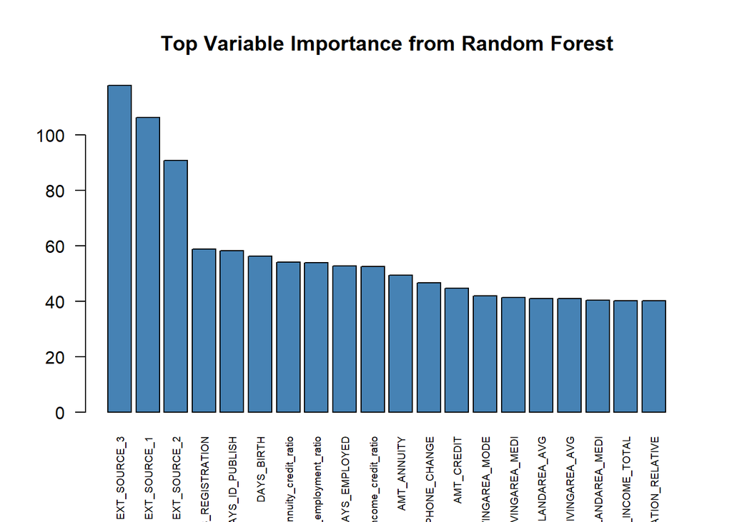

```r
# Top 20 features based on RF model
top_n <- 20
important_vars <- head(sort(rf_model$variable.importance, decreasing = TRUE), top_n)

# Bar Plot
barplot(important_vars, las = 2, main = "Top Variable Importance from Random Forest", col = "steelblue", cex.names = 0.58)
```

```r
## Many of the variables have low importance, removing bottom 25% of features.

# Extract variable importances from the random forest model
feature_importances <- rf_model$variable.importance

# Threshold 1st quartile
threshold <- quantile(feature_importances, 0.25)

# Identify columns to be removed
cols_to_remove <- names(feature_importances[feature_importances < threshold])

# Remove the identified columns from clean5
clean6 <- clean5[, !(names(clean5) %in% cols_to_remove)]


## removing columns 36-66 due to near-zero variance and high volume of missing data
clean7 <- clean6 %>%
  select(-c(36:66))

## clean7 notes: features selected (RF). Outliers removed. Data structure explored.

# Looking at remaining predictors and columns with missing data
clean7 %>% skim() %>% kable()
```

| skim_type | skim_variable | n_missing | complete_rate | factor.ordered | factor.n_unique | factor.top_counts | numeric.mean | numeric.sd | numeric.p0 | numeric.p25 | numeric.p50 | numeric.p75 | numeric.p100 | numeric.hist |
| --- | --- | --- | --- | --- | --- | --- | --- | --- | --- | --- | --- | --- | --- | --- |
| factor | CODE_GENDER | 0 | 1.0000000 | FALSE | 3 | F: 202446, M: 105059, XNA: 4 | NA | NA | NA | NA | NA | NA | NA | NA |
| factor | FLAG_OWN_CAR | 0 | 1.0000000 | FALSE | 2 | N: 202922, Y: 104587 | NA | NA | NA | NA | NA | NA | NA | NA |
| factor | FLAG_OWN_REALTY | 0 | 1.0000000 | FALSE | 2 | Y: 213311, N: 94198 | NA | NA | NA | NA | NA | NA | NA | NA |
| factor | NAME_TYPE_SUITE | 0 | 1.0000000 | FALSE | 8 | Una: 248525, Fam: 40148, Spo: 11370, Chi: 3267 | NA | NA | NA | NA | NA | NA | NA | NA |
| factor | NAME_INCOME_TYPE | 0 | 1.0000000 | FALSE | 8 | Wor: 158772, Com: 71617, Pen: 55362, Sta: 21703 | NA | NA | NA | NA | NA | NA | NA | NA |
| factor | NAME_EDUCATION_TYPE | 0 | 1.0000000 | FALSE | 5 | Sec: 218390, Hig: 74862, Inc: 10277, Low: 3816 | NA | NA | NA | NA | NA | NA | NA | NA |
| factor | NAME_FAMILY_STATUS | 0 | 1.0000000 | FALSE | 6 | Mar: 196432, Sin: 45444, Civ: 29774, Sep: 19769 | NA | NA | NA | NA | NA | NA | NA | NA |
| factor | NAME_HOUSING_TYPE | 0 | 1.0000000 | FALSE | 6 | Hou: 272866, Wit: 14840, Mun: 11183, Ren: 4881 | NA | NA | NA | NA | NA | NA | NA | NA |
| factor | OCCUPATION_TYPE | 0 | 1.0000000 | FALSE | 19 | emp: 96390, Lab: 55186, Sal: 32101, Cor: 27570 | NA | NA | NA | NA | NA | NA | NA | NA |
| factor | WEEKDAY_APPR_PROCESS_START | 0 | 1.0000000 | FALSE | 7 | TUE: 53901, WED: 51934, MON: 50713, THU: 50591 | NA | NA | NA | NA | NA | NA | NA | NA |
| factor | ORGANIZATION_TYPE | 0 | 1.0000000 | FALSE | 58 | Bus: 67992, XNA: 55374, Sel: 38411, Oth: 16683 | NA | NA | NA | NA | NA | NA | NA | NA |
| numeric | TARGET | 0 | 1.0000000 | NA | NA | NA | 8.072610e-02 | 2.724144e-01 | 0.000000e+00 | 0.000000e+00 | 0.000000e+00 | 0.000000e+00 | 1.000000e+00 | ▇▁▁▁▁ |
| numeric | CNT_CHILDREN | 0 | 1.0000000 | NA | NA | NA | 4.166089e-01 | 7.172683e-01 | 0.000000e+00 | 0.000000e+00 | 0.000000e+00 | 1.000000e+00 | 5.000000e+00 | ▇▁▁▁▁ |
| numeric | AMT_INCOME_TOTAL | 0 | 1.0000000 | NA | NA | NA | 1.660260e+05 | 8.306367e+04 | 2.565000e+04 | 1.125000e+05 | 1.471500e+05 | 2.025000e+05 | 4.725000e+05 | ▆▇▃▁▁ |
| numeric | AMT_CREDIT | 0 | 1.0000000 | NA | NA | NA | 5.990263e+05 | 4.024906e+05 | 4.500000e+04 | 2.700000e+05 | 5.135310e+05 | 8.086500e+05 | 4.050000e+06 | ▇▂▁▁▁ |
| numeric | AMT_ANNUITY | 12 | 0.9999610 | NA | NA | NA | 2.710861e+04 | 1.449373e+04 | 1.615500e+03 | 1.652400e+04 | 2.490300e+04 | 3.459600e+04 | 2.580255e+05 | ▇▁▁▁▁ |
| numeric | AMT_GOODS_PRICE | 278 | 0.9990960 | NA | NA | NA | 5.383964e+05 | 3.694463e+05 | 4.050000e+04 | 2.385000e+05 | 4.500000e+05 | 6.795000e+05 | 4.050000e+06 | ▇▂▁▁▁ |
| numeric | REGION_POPULATION_RELATIVE | 0 | 1.0000000 | NA | NA | NA | 2.086810e-02 | 1.383130e-02 | 2.900000e-04 | 1.000600e-02 | 1.885000e-02 | 2.866300e-02 | 7.250800e-02 | ▇▇▃▁▁ |
| numeric | DAYS_BIRTH | 0 | 1.0000000 | NA | NA | NA | 1.603701e+04 | 4.363998e+03 | 7.489000e+03 | 1.241300e+04 | 1.575000e+04 | 1.968200e+04 | 2.522900e+04 | ▅▇▇▆▃ |
| numeric | DAYS_EMPLOYED | 0 | 1.0000000 | NA | NA | NA | 2.251621e+03 | 2.136193e+03 | 1.000000e+00 | 9.330000e+02 | 1.648000e+03 | 2.760000e+03 | 1.791200e+04 | ▇▁▁▁▁ |
| numeric | DAYS_REGISTRATION | 0 | 1.0000000 | NA | NA | NA | 4.986131e+03 | 3.522894e+03 | 0.000000e+00 | 2.010000e+03 | 4.504000e+03 | 7.480000e+03 | 2.467200e+04 | ▇▅▂▁▁ |
| numeric | DAYS_ID_PUBLISH | 0 | 1.0000000 | NA | NA | NA | 2.994193e+03 | 1.509451e+03 | 0.000000e+00 | 1.720000e+03 | 3.254000e+03 | 4.299000e+03 | 7.197000e+03 | ▅▆▇▆▁ |
| numeric | FLAG_WORK_PHONE | 0 | 1.0000000 | NA | NA | NA | 1.993665e-01 | 3.995248e-01 | 0.000000e+00 | 0.000000e+00 | 0.000000e+00 | 0.000000e+00 | 1.000000e+00 | ▇▁▁▁▂ |
| numeric | FLAG_PHONE | 0 | 1.0000000 | NA | NA | NA | 2.810649e-01 | 4.495199e-01 | 0.000000e+00 | 0.000000e+00 | 0.000000e+00 | 1.000000e+00 | 1.000000e+00 | ▇▁▁▁▃ |
| numeric | FLAG_EMAIL | 0 | 1.0000000 | NA | NA | NA | 5.672030e-02 | 2.313077e-01 | 0.000000e+00 | 0.000000e+00 | 0.000000e+00 | 0.000000e+00 | 1.000000e+00 | ▇▁▁▁▁ |
| numeric | CNT_FAM_MEMBERS | 2 | 0.9999935 | NA | NA | NA | 2.152660e+00 | 9.106820e-01 | 1.000000e+00 | 2.000000e+00 | 2.000000e+00 | 3.000000e+00 | 2.000000e+01 | ▇▁▁▁▁ |
| numeric | REGION_RATING_CLIENT | 0 | 1.0000000 | NA | NA | NA | 2.052463e+00 | 5.090355e-01 | 1.000000e+00 | 2.000000e+00 | 2.000000e+00 | 2.000000e+00 | 3.000000e+00 | ▁▁▇▁▂ |
| numeric | REGION_RATING_CLIENT_W_CITY | 0 | 1.0000000 | NA | NA | NA | 2.031521e+00 | 5.027387e-01 | 1.000000e+00 | 2.000000e+00 | 2.000000e+00 | 2.000000e+00 | 3.000000e+00 | ▁▁▇▁▂ |
| numeric | HOUR_APPR_PROCESS_START | 0 | 1.0000000 | NA | NA | NA | 1.206344e+01 | 3.265833e+00 | 0.000000e+00 | 1.000000e+01 | 1.200000e+01 | 1.400000e+01 | 2.300000e+01 | ▁▃▇▆▁ |
| numeric | REG_CITY_NOT_LIVE_CITY | 0 | 1.0000000 | NA | NA | NA | 7.817010e-02 | 2.684395e-01 | 0.000000e+00 | 0.000000e+00 | 0.000000e+00 | 0.000000e+00 | 1.000000e+00 | ▇▁▁▁▁ |
| numeric | REG_CITY_NOT_WORK_CITY | 0 | 1.0000000 | NA | NA | NA | 2.304550e-01 | 4.211248e-01 | 0.000000e+00 | 0.000000e+00 | 0.000000e+00 | 0.000000e+00 | 1.000000e+00 | ▇▁▁▁▂ |
| numeric | LIVE_CITY_NOT_WORK_CITY | 0 | 1.0000000 | NA | NA | NA | 1.795525e-01 | 3.838149e-01 | 0.000000e+00 | 0.000000e+00 | 0.000000e+00 | 0.000000e+00 | 1.000000e+00 | ▇▁▁▁▂ |
| numeric | EXT_SOURCE_1 | 173377 | 0.4361889 | NA | NA | NA | 5.021305e-01 | 2.110629e-01 | 1.456810e-02 | 3.340073e-01 | 5.059979e-01 | 6.750550e-01 | 9.626928e-01 | ▂▇▇▇▃ |
| numeric | EXT_SOURCE_2 | 660 | 0.9978537 | NA | NA | NA | 5.143932e-01 | 1.910605e-01 | 1.000000e-07 | 3.924574e-01 | 5.659668e-01 | 6.636171e-01 | 8.549997e-01 | ▂▂▃▇▃ |
| numeric | EXT_SOURCE_3 | 60965 | 0.8017456 | NA | NA | NA | 5.108530e-01 | 1.948449e-01 | 5.273000e-04 | 3.706496e-01 | 5.352763e-01 | 6.690567e-01 | 8.960095e-01 | ▂▃▆▇▃ |
| numeric | OBS_30_CNT_SOCIAL_CIRCLE | 1021 | 0.9966798 | NA | NA | NA | 1.422255e+00 | 2.400994e+00 | 0.000000e+00 | 0.000000e+00 | 0.000000e+00 | 2.000000e+00 | 3.480000e+02 | ▇▁▁▁▁ |
| numeric | DEF_30_CNT_SOCIAL_CIRCLE | 1021 | 0.9966798 | NA | NA | NA | 1.434216e-01 | 4.466997e-01 | 0.000000e+00 | 0.000000e+00 | 0.000000e+00 | 0.000000e+00 | 3.400000e+01 | ▇▁▁▁▁ |
| numeric | OBS_60_CNT_SOCIAL_CIRCLE | 1021 | 0.9966798 | NA | NA | NA | 1.405301e+00 | 2.379808e+00 | 0.000000e+00 | 0.000000e+00 | 0.000000e+00 | 2.000000e+00 | 3.440000e+02 | ▇▁▁▁▁ |
| numeric | DEF_60_CNT_SOCIAL_CIRCLE | 1021 | 0.9966798 | NA | NA | NA | 1.000496e-01 | 3.622919e-01 | 0.000000e+00 | 0.000000e+00 | 0.000000e+00 | 0.000000e+00 | 2.400000e+01 | ▇▁▁▁▁ |
| numeric | DAYS_LAST_PHONE_CHANGE | 1 | 0.9999967 | NA | NA | NA | 9.628631e+02 | 8.268091e+02 | 0.000000e+00 | 2.740000e+02 | 7.570000e+02 | 1.570000e+03 | 4.292000e+03 | ▇▃▂▁▁ |
| numeric | FLAG_DOCUMENT_3 | 0 | 1.0000000 | NA | NA | NA | 7.100215e-01 | 4.537528e-01 | 0.000000e+00 | 0.000000e+00 | 1.000000e+00 | 1.000000e+00 | 1.000000e+00 | ▃▁▁▁▇ |
| numeric | FLAG_DOCUMENT_8 | 0 | 1.0000000 | NA | NA | NA | 8.137650e-02 | 2.734129e-01 | 0.000000e+00 | 0.000000e+00 | 0.000000e+00 | 0.000000e+00 | 1.000000e+00 | ▇▁▁▁▁ |
| numeric | AMT_REQ_CREDIT_BUREAU_WEEK | 41519 | 0.8649828 | NA | NA | NA | 3.436220e-02 | 2.046856e-01 | 0.000000e+00 | 0.000000e+00 | 0.000000e+00 | 0.000000e+00 | 8.000000e+00 | ▇▁▁▁▁ |
| numeric | AMT_REQ_CREDIT_BUREAU_MON | 41519 | 0.8649828 | NA | NA | NA | 2.673973e-01 | 9.160055e-01 | 0.000000e+00 | 0.000000e+00 | 0.000000e+00 | 0.000000e+00 | 2.700000e+01 | ▇▁▁▁▁ |
| numeric | AMT_REQ_CREDIT_BUREAU_QRT | 41519 | 0.8649828 | NA | NA | NA | 2.529719e-01 | 5.609320e-01 | 0.000000e+00 | 0.000000e+00 | 0.000000e+00 | 0.000000e+00 | 2.000000e+00 | ▇▁▁▁▁ |
| numeric | AMT_REQ_CREDIT_BUREAU_YEAR | 41519 | 0.8649828 | NA | NA | NA | 1.899970e+00 | 1.869297e+00 | 0.000000e+00 | 0.000000e+00 | 1.000000e+00 | 3.000000e+00 | 2.500000e+01 | ▇▁▁▁▁ |
| numeric | income_credit_ratio | 0 | 1.0000000 | NA | NA | NA | 3.959953e-01 | 3.277282e-01 | 1.180120e-02 | 1.936033e-01 | 3.052632e-01 | 4.932953e-01 | 1.050000e+01 | ▇▁▁▁▁ |
| numeric | annuity_credit_ratio | 12 | 0.9999610 | NA | NA | NA | 5.369500e-02 | 2.248130e-02 | 2.207260e-02 | 3.690040e-02 | 5.000000e-02 | 6.404310e-02 | 1.244296e-01 | ▇▇▃▁▁ |
| numeric | age_employment_ratio | 0 | 1.0000000 | NA | NA | NA | 1.706293e+01 | 6.185614e+01 | 1.372097e+00 | 5.234070e+00 | 1.098422e+01 | 1.495838e+01 | 2.379800e+04 | ▇▁▁▁▁ |

## Imputation

| skim_type | skim_variable | n_missing | complete_rate | factor.ordered | factor.n_unique | factor.top_counts | numeric.mean | numeric.sd | numeric.p0 | numeric.p25 | numeric.p50 | numeric.p75 | numeric.p100 | numeric.hist |
| --- | --- | --- | --- | --- | --- | --- | --- | --- | --- | --- | --- | --- | --- | --- |
| factor | CODE_GENDER | 0 | 1 | FALSE | 3 | F: 202446, M: 105059, XNA: 4 | NA | NA | NA | NA | NA | NA | NA | NA |
| factor | FLAG_OWN_CAR | 0 | 1 | FALSE | 2 | N: 202922, Y: 104587 | NA | NA | NA | NA | NA | NA | NA | NA |
| factor | FLAG_OWN_REALTY | 0 | 1 | FALSE | 2 | Y: 213311, N: 94198 | NA | NA | NA | NA | NA | NA | NA | NA |
| factor | NAME_TYPE_SUITE | 0 | 1 | FALSE | 8 | Una: 248525, Fam: 40148, Spo: 11370, Chi: 3267 | NA | NA | NA | NA | NA | NA | NA | NA |
| factor | NAME_INCOME_TYPE | 0 | 1 | FALSE | 8 | Wor: 158772, Com: 71617, Pen: 55362, Sta: 21703 | NA | NA | NA | NA | NA | NA | NA | NA |
| factor | NAME_EDUCATION_TYPE | 0 | 1 | FALSE | 5 | Sec: 218390, Hig: 74862, Inc: 10277, Low: 3816 | NA | NA | NA | NA | NA | NA | NA | NA |
| factor | NAME_FAMILY_STATUS | 0 | 1 | FALSE | 6 | Mar: 196432, Sin: 45444, Civ: 29774, Sep: 19769 | NA | NA | NA | NA | NA | NA | NA | NA |
| factor | NAME_HOUSING_TYPE | 0 | 1 | FALSE | 6 | Hou: 272866, Wit: 14840, Mun: 11183, Ren: 4881 | NA | NA | NA | NA | NA | NA | NA | NA |
| factor | OCCUPATION_TYPE | 0 | 1 | FALSE | 19 | emp: 96390, Lab: 55186, Sal: 32101, Cor: 27570 | NA | NA | NA | NA | NA | NA | NA | NA |
| factor | WEEKDAY_APPR_PROCESS_START | 0 | 1 | FALSE | 7 | TUE: 53901, WED: 51934, MON: 50713, THU: 50591 | NA | NA | NA | NA | NA | NA | NA | NA |
| factor | ORGANIZATION_TYPE | 0 | 1 | FALSE | 58 | Bus: 67992, XNA: 55374, Sel: 38411, Oth: 16683 | NA | NA | NA | NA | NA | NA | NA | NA |
| numeric | TARGET | 0 | 1 | NA | NA | NA | 8.072610e-02 | 2.724144e-01 | 0.000000e+00 | 0.000000e+00 | 0.000000e+00 | 0.000000e+00 | 1.000000e+00 | ▇▁▁▁▁ |
| numeric | CNT_CHILDREN | 0 | 1 | NA | NA | NA | 4.166089e-01 | 7.172683e-01 | 0.000000e+00 | 0.000000e+00 | 0.000000e+00 | 1.000000e+00 | 5.000000e+00 | ▇▁▁▁▁ |
| numeric | AMT_INCOME_TOTAL | 0 | 1 | NA | NA | NA | 1.660260e+05 | 8.306367e+04 | 2.565000e+04 | 1.125000e+05 | 1.471500e+05 | 2.025000e+05 | 4.725000e+05 | ▆▇▃▁▁ |
| numeric | AMT_CREDIT | 0 | 1 | NA | NA | NA | 5.990263e+05 | 4.024906e+05 | 4.500000e+04 | 2.700000e+05 | 5.135310e+05 | 8.086500e+05 | 4.050000e+06 | ▇▂▁▁▁ |
| numeric | AMT_ANNUITY | 0 | 1 | NA | NA | NA | 2.710852e+04 | 1.449345e+04 | 1.615500e+03 | 1.652400e+04 | 2.490300e+04 | 3.459600e+04 | 2.580255e+05 | ▇▁▁▁▁ |
| numeric | AMT_GOODS_PRICE | 0 | 1 | NA | NA | NA | 5.383165e+05 | 3.692888e+05 | 4.050000e+04 | 2.385000e+05 | 4.500000e+05 | 6.795000e+05 | 4.050000e+06 | ▇▂▁▁▁ |
| numeric | REGION_POPULATION_RELATIVE | 0 | 1 | NA | NA | NA | 2.086810e-02 | 1.383130e-02 | 2.900000e-04 | 1.000600e-02 | 1.885000e-02 | 2.866300e-02 | 7.250800e-02 | ▇▇▃▁▁ |
| numeric | DAYS_BIRTH | 0 | 1 | NA | NA | NA | 1.603701e+04 | 4.363998e+03 | 7.489000e+03 | 1.241300e+04 | 1.575000e+04 | 1.968200e+04 | 2.522900e+04 | ▅▇▇▆▃ |
| numeric | DAYS_EMPLOYED | 0 | 1 | NA | NA | NA | 2.251621e+03 | 2.136193e+03 | 1.000000e+00 | 9.330000e+02 | 1.648000e+03 | 2.760000e+03 | 1.791200e+04 | ▇▁▁▁▁ |
| numeric | DAYS_REGISTRATION | 0 | 1 | NA | NA | NA | 4.986131e+03 | 3.522894e+03 | 0.000000e+00 | 2.010000e+03 | 4.504000e+03 | 7.480000e+03 | 2.467200e+04 | ▇▅▂▁▁ |
| numeric | DAYS_ID_PUBLISH | 0 | 1 | NA | NA | NA | 2.994193e+03 | 1.509451e+03 | 0.000000e+00 | 1.720000e+03 | 3.254000e+03 | 4.299000e+03 | 7.197000e+03 | ▅▆▇▆▁ |
| numeric | FLAG_WORK_PHONE | 0 | 1 | NA | NA | NA | 1.993665e-01 | 3.995248e-01 | 0.000000e+00 | 0.000000e+00 | 0.000000e+00 | 0.000000e+00 | 1.000000e+00 | ▇▁▁▁▂ |
| numeric | FLAG_PHONE | 0 | 1 | NA | NA | NA | 2.810649e-01 | 4.495199e-01 | 0.000000e+00 | 0.000000e+00 | 0.000000e+00 | 1.000000e+00 | 1.000000e+00 | ▇▁▁▁▃ |
| numeric | FLAG_EMAIL | 0 | 1 | NA | NA | NA | 5.672030e-02 | 2.313077e-01 | 0.000000e+00 | 0.000000e+00 | 0.000000e+00 | 0.000000e+00 | 1.000000e+00 | ▇▁▁▁▁ |
| numeric | CNT_FAM_MEMBERS | 0 | 1 | NA | NA | NA | 2.152660e+00 | 9.106790e-01 | 1.000000e+00 | 2.000000e+00 | 2.000000e+00 | 3.000000e+00 | 2.000000e+01 | ▇▁▁▁▁ |
| numeric | REGION_RATING_CLIENT | 0 | 1 | NA | NA | NA | 2.052463e+00 | 5.090355e-01 | 1.000000e+00 | 2.000000e+00 | 2.000000e+00 | 2.000000e+00 | 3.000000e+00 | ▁▁▇▁▂ |
| numeric | REGION_RATING_CLIENT_W_CITY | 0 | 1 | NA | NA | NA | 2.031521e+00 | 5.027387e-01 | 1.000000e+00 | 2.000000e+00 | 2.000000e+00 | 2.000000e+00 | 3.000000e+00 | ▁▁▇▁▂ |
| numeric | HOUR_APPR_PROCESS_START | 0 | 1 | NA | NA | NA | 1.206344e+01 | 3.265833e+00 | 0.000000e+00 | 1.000000e+01 | 1.200000e+01 | 1.400000e+01 | 2.300000e+01 | ▁▃▇▆▁ |
| numeric | REG_CITY_NOT_LIVE_CITY | 0 | 1 | NA | NA | NA | 7.817010e-02 | 2.684395e-01 | 0.000000e+00 | 0.000000e+00 | 0.000000e+00 | 0.000000e+00 | 1.000000e+00 | ▇▁▁▁▁ |
| numeric | REG_CITY_NOT_WORK_CITY | 0 | 1 | NA | NA | NA | 2.304550e-01 | 4.211248e-01 | 0.000000e+00 | 0.000000e+00 | 0.000000e+00 | 0.000000e+00 | 1.000000e+00 | ▇▁▁▁▂ |
| numeric | LIVE_CITY_NOT_WORK_CITY | 0 | 1 | NA | NA | NA | 1.795525e-01 | 3.838149e-01 | 0.000000e+00 | 0.000000e+00 | 0.000000e+00 | 0.000000e+00 | 1.000000e+00 | ▇▁▁▁▂ |
| numeric | EXT_SOURCE_1 | 0 | 1 | NA | NA | NA | 5.043110e-01 | 1.394085e-01 | 1.456810e-02 | 5.059979e-01 | 5.059979e-01 | 5.059979e-01 | 9.626928e-01 | ▁▁▇▂▁ |
| numeric | EXT_SOURCE_2 | 0 | 1 | NA | NA | NA | 5.145038e-01 | 1.908702e-01 | 1.000000e-07 | 3.929737e-01 | 5.659668e-01 | 6.634218e-01 | 8.549997e-01 | ▂▂▃▇▃ |
| numeric | EXT_SOURCE_3 | 0 | 1 | NA | NA | NA | 5.108530e-01 | 1.744645e-01 | 5.273000e-04 | 4.170997e-01 | 5.108530e-01 | 6.363762e-01 | 8.960095e-01 | ▁▂▇▅▂ |
| numeric | OBS_30_CNT_SOCIAL_CIRCLE | 0 | 1 | NA | NA | NA | 1.417533e+00 | 2.398401e+00 | 0.000000e+00 | 0.000000e+00 | 0.000000e+00 | 2.000000e+00 | 3.480000e+02 | ▇▁▁▁▁ |
| numeric | DEF_30_CNT_SOCIAL_CIRCLE | 0 | 1 | NA | NA | NA | 1.429454e-01 | 4.460339e-01 | 0.000000e+00 | 0.000000e+00 | 0.000000e+00 | 0.000000e+00 | 3.400000e+01 | ▇▁▁▁▁ |
| numeric | OBS_60_CNT_SOCIAL_CIRCLE | 0 | 1 | NA | NA | NA | 1.400635e+00 | 2.377229e+00 | 0.000000e+00 | 0.000000e+00 | 0.000000e+00 | 2.000000e+00 | 3.440000e+02 | ▇▁▁▁▁ |
| numeric | DEF_60_CNT_SOCIAL_CIRCLE | 0 | 1 | NA | NA | NA | 9.971740e-02 | 3.617357e-01 | 0.000000e+00 | 0.000000e+00 | 0.000000e+00 | 0.000000e+00 | 2.400000e+01 | ▇▁▁▁▁ |
| numeric | DAYS_LAST_PHONE_CHANGE | 0 | 1 | NA | NA | NA | 9.628624e+02 | 8.268079e+02 | 0.000000e+00 | 2.740000e+02 | 7.570000e+02 | 1.570000e+03 | 4.292000e+03 | ▇▃▂▁▁ |
| numeric | FLAG_DOCUMENT_3 | 0 | 1 | NA | NA | NA | 7.100215e-01 | 4.537528e-01 | 0.000000e+00 | 0.000000e+00 | 1.000000e+00 | 1.000000e+00 | 1.000000e+00 | ▃▁▁▁▇ |
| numeric | FLAG_DOCUMENT_8 | 0 | 1 | NA | NA | NA | 8.137650e-02 | 2.734129e-01 | 0.000000e+00 | 0.000000e+00 | 0.000000e+00 | 0.000000e+00 | 1.000000e+00 | ▇▁▁▁▁ |
| numeric | AMT_REQ_CREDIT_BUREAU_WEEK | 0 | 1 | NA | NA | NA | 2.972270e-02 | 1.907285e-01 | 0.000000e+00 | 0.000000e+00 | 0.000000e+00 | 0.000000e+00 | 8.000000e+00 | ▇▁▁▁▁ |
| numeric | AMT_REQ_CREDIT_BUREAU_MON | 0 | 1 | NA | NA | NA | 2.312940e-01 | 8.568127e-01 | 0.000000e+00 | 0.000000e+00 | 0.000000e+00 | 0.000000e+00 | 2.700000e+01 | ▇▁▁▁▁ |
| numeric | AMT_REQ_CREDIT_BUREAU_QRT | 0 | 1 | NA | NA | NA | 2.188164e-01 | 5.288061e-01 | 0.000000e+00 | 0.000000e+00 | 0.000000e+00 | 0.000000e+00 | 2.000000e+00 | ▇▁▁▁▁ |
| numeric | AMT_REQ_CREDIT_BUREAU_YEAR | 0 | 1 | NA | NA | NA | 1.778458e+00 | 1.765524e+00 | 0.000000e+00 | 1.000000e+00 | 1.000000e+00 | 3.000000e+00 | 2.500000e+01 | ▇▁▁▁▁ |
| numeric | income_credit_ratio | 0 | 1 | NA | NA | NA | 3.959953e-01 | 3.277282e-01 | 1.180120e-02 | 1.936033e-01 | 3.052632e-01 | 4.932953e-01 | 1.050000e+01 | ▇▁▁▁▁ |
| numeric | annuity_credit_ratio | 0 | 1 | NA | NA | NA | 5.369490e-02 | 2.248080e-02 | 2.207260e-02 | 3.690040e-02 | 5.000000e-02 | 6.404280e-02 | 1.244296e-01 | ▇▇▃▁▁ |
| numeric | age_employment_ratio | 0 | 1 | NA | NA | NA | 1.706293e+01 | 6.185614e+01 | 1.372097e+00 | 5.234070e+00 | 1.098422e+01 | 1.495838e+01 | 2.379800e+04 | ▇▁▁▁▁ |

```r
## Checking to see if feature importance is retained

# RF Formula
all_predictors3 <- setdiff(names(clean8), "TARGET")
formula_rf3 <- as.formula(paste("TARGET ~", paste(all_predictors3, collapse = " + ")))

# RF model on new temp data
rf_model3 <- ranger(formula = formula_rf3,
                   data = clean8,
                   num.trees = 100,
                   importance = 'impurity')

# Check feature importance
rf_model3$variable.importance
```

```
##                 CODE_GENDER                FLAG_OWN_CAR
##                   107.15908                   102.21707
##             FLAG_OWN_REALTY                CNT_CHILDREN
##                   105.51349                   168.04976
##            AMT_INCOME_TOTAL                  AMT_CREDIT
##                   633.85901                   731.28662
##                 AMT_ANNUITY             AMT_GOODS_PRICE
##                   827.77603                   609.10848
##             NAME_TYPE_SUITE            NAME_INCOME_TYPE
##                   161.35176                   133.32263
##         NAME_EDUCATION_TYPE          NAME_FAMILY_STATUS
##                   147.15150                   253.44783
##           NAME_HOUSING_TYPE  REGION_POPULATION_RELATIVE
##                   153.68367                   685.56088
##                  DAYS_BIRTH               DAYS_EMPLOYED
##                   948.02985                   830.58879
##           DAYS_REGISTRATION             DAYS_ID_PUBLISH
##                   934.24804                   947.97490
##             FLAG_WORK_PHONE                  FLAG_PHONE
##                   101.46623                    98.19518
##                  FLAG_EMAIL             OCCUPATION_TYPE
##                    59.63922                   397.35261
##             CNT_FAM_MEMBERS        REGION_RATING_CLIENT
##                   242.31604                   113.79993
## REGION_RATING_CLIENT_W_CITY  WEEKDAY_APPR_PROCESS_START
##                   117.18477                   373.82809
##     HOUR_APPR_PROCESS_START      REG_CITY_NOT_LIVE_CITY
##                   588.66733                    85.14696
##      REG_CITY_NOT_WORK_CITY     LIVE_CITY_NOT_WORK_CITY
##                    87.15942                    84.45762
##           ORGANIZATION_TYPE                EXT_SOURCE_1
##                   498.30506                   703.53240
##                EXT_SOURCE_2                EXT_SOURCE_3
##                  1451.84814                  1308.64190
##    OBS_30_CNT_SOCIAL_CIRCLE    DEF_30_CNT_SOCIAL_CIRCLE
##                   297.48202                   126.39644
##    OBS_60_CNT_SOCIAL_CIRCLE    DEF_60_CNT_SOCIAL_CIRCLE
##                   301.46484                   107.04367
##      DAYS_LAST_PHONE_CHANGE             FLAG_DOCUMENT_3
##                   808.90619                    89.34024
##             FLAG_DOCUMENT_8  AMT_REQ_CREDIT_BUREAU_WEEK
##                    47.85086                    52.34173
##   AMT_REQ_CREDIT_BUREAU_MON   AMT_REQ_CREDIT_BUREAU_QRT
##                   134.94125                   125.16397
##  AMT_REQ_CREDIT_BUREAU_YEAR         income_credit_ratio
##                   389.82737                   865.35859
##        annuity_credit_ratio        age_employment_ratio
##                   891.26786                   896.12778
```

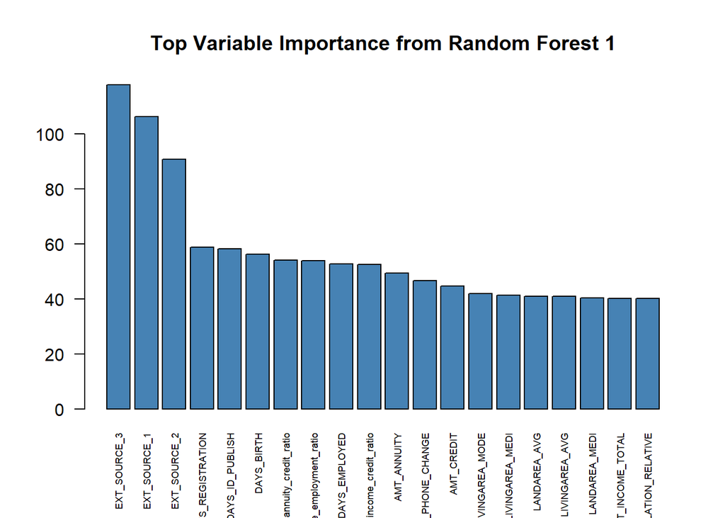

```r
# Top 20 features based on RF model
top_n <- 20
important_vars3 <- head(sort(rf_model3$variable.importance, decreasing = TRUE), top_n)

# Bar Plot
barplot(important_vars, las = 2, main = "Top Variable Importance from Random Forest 1", col = "steelblue", cex.names = 0.55)
```

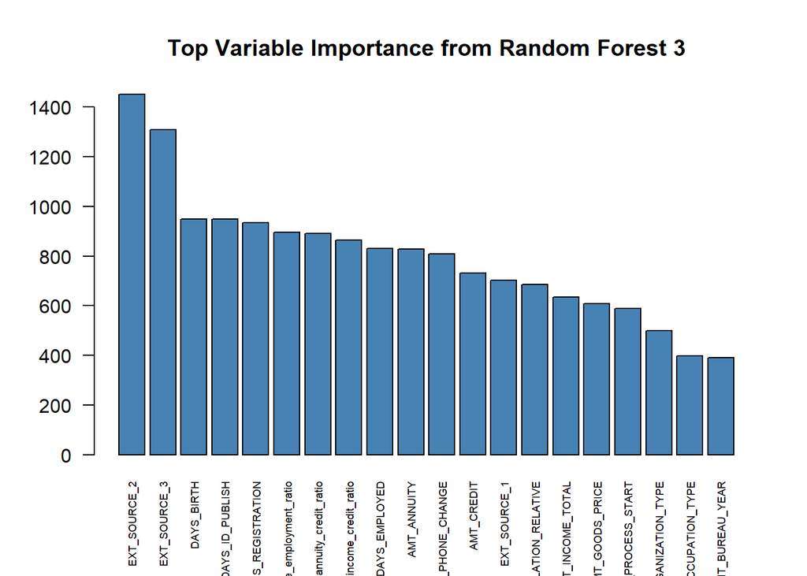

```r
barplot(important_vars3, las = 2, main = "Top Variable Importance from Random Forest 3", col = "steelblue", cex.names = 0.55)
```

```r
# Important predictors changed slightly, but not significantly
```

## Visualizations

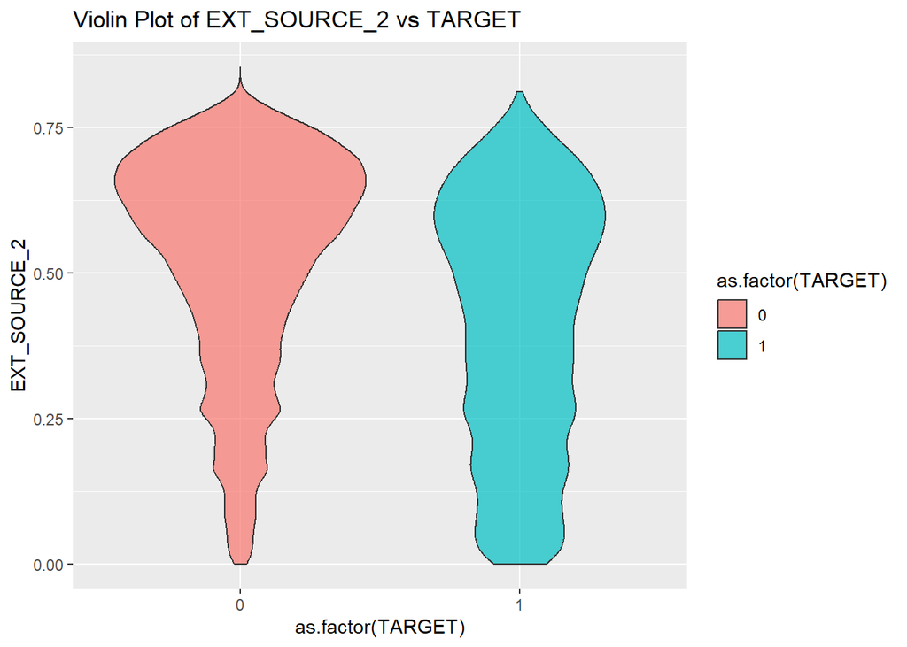

```r
# Violin Plot for EXT_SOURCE_2 vs TARGET
ggplot(clean8, aes(x=as.factor(TARGET), y=EXT_SOURCE_2, fill=as.factor(TARGET))) +
  geom_violin(alpha=0.7) +
  ggtitle("Violin Plot of EXT_SOURCE_2 vs TARGET")
```

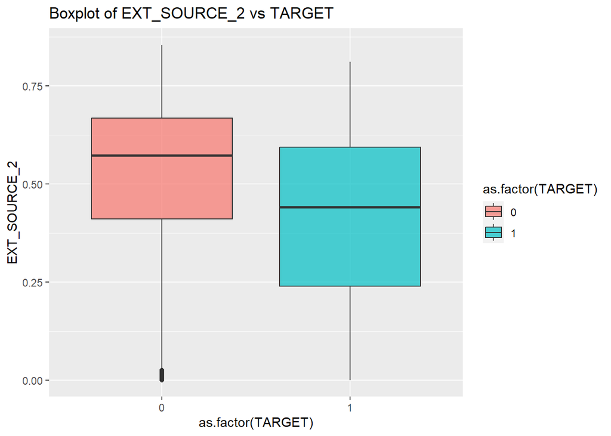

```r
# Boxplot for EXT_SOURCE_2 vs TARGET
ggplot(clean8, aes(x=as.factor(TARGET), y=EXT_SOURCE_2, fill=as.factor(TARGET))) +
  geom_boxplot(alpha=0.7) +
  ggtitle("Boxplot of EXT_SOURCE_2 vs TARGET")
```

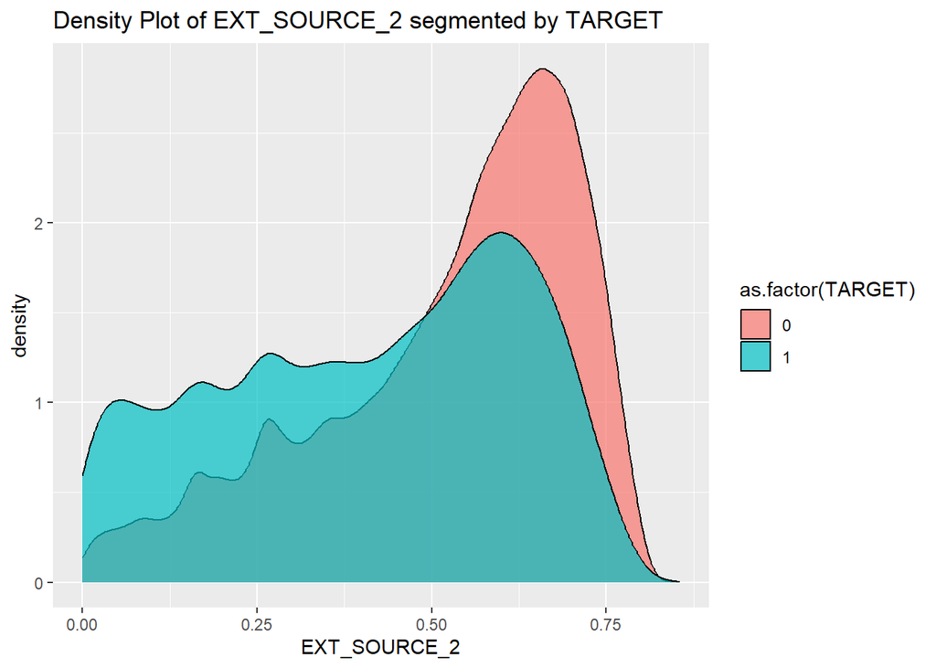

```r
# Density Plot for EXT_SOURCE_2 segmented by TARGET
ggplot(clean8, aes(x=EXT_SOURCE_2, fill=as.factor(TARGET))) +
  geom_density(alpha=0.7) +
  ggtitle("Density Plot of EXT_SOURCE_2 segmented by TARGET")
```

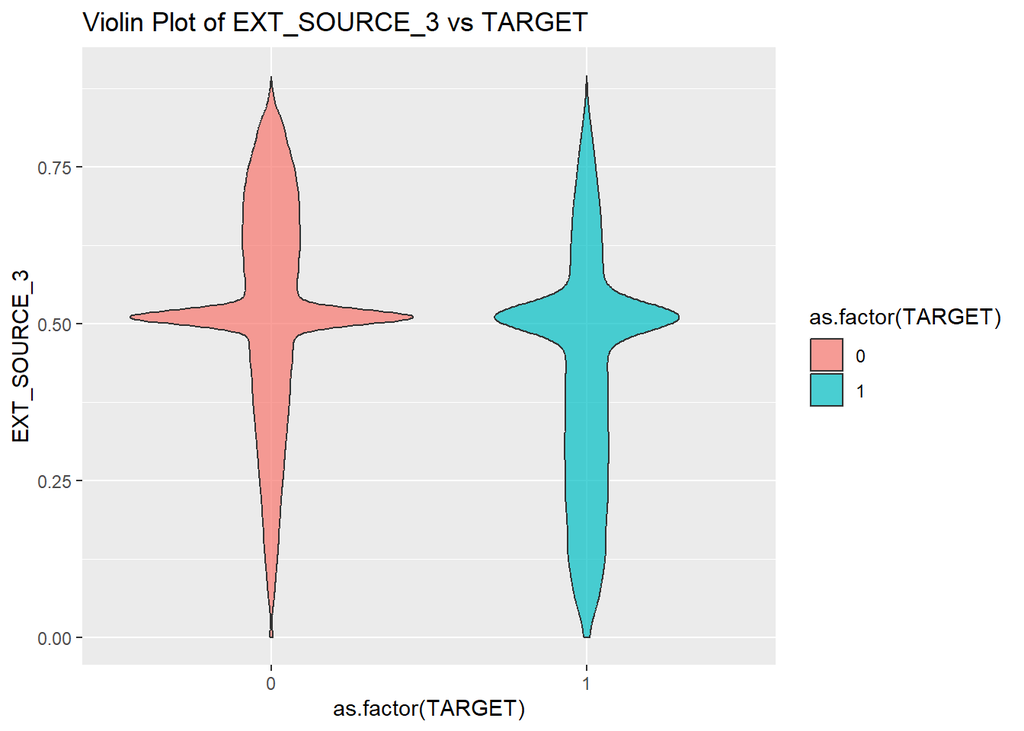

```r
# Violin Plot for EXT_SOURCE_31 vs TARGET
ggplot(clean8, aes(x=as.factor(TARGET), y=EXT_SOURCE_3, fill=as.factor(TARGET))) +
  geom_violin(alpha=0.7) +
  ggtitle("Violin Plot of EXT_SOURCE_3 vs TARGET")
```

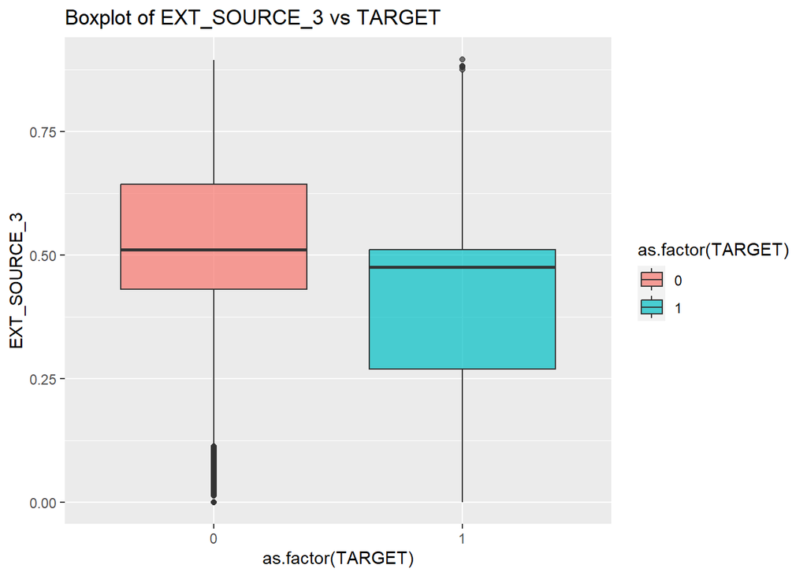

```r
# Boxplot for EXT_SOURCE_3 vs TARGET
ggplot(clean8, aes(x=as.factor(TARGET), y=EXT_SOURCE_3, fill=as.factor(TARGET))) +
  geom_boxplot(alpha=0.7) +
  ggtitle("Boxplot of EXT_SOURCE_3 vs TARGET")
```

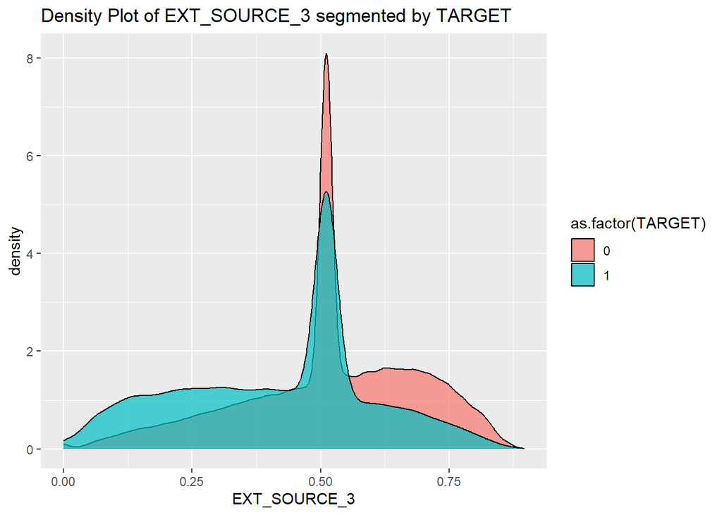

```r
# Density Plot for EXT_SOURCE_3 segmented by TARGET
ggplot(clean8, aes(x=EXT_SOURCE_3, fill=as.factor(TARGET))) +
  geom_density(alpha=0.7) +
  ggtitle("Density Plot of EXT_SOURCE_3 segmented by TARGET")
```

## Joining Transactional Data

```r
bureau_aggregated <- bureau %>%
  group_by(SK_ID_CURR) %>%
  summarize(
    avg_credit = mean(AMT_CREDIT_SUM, na.rm = TRUE),
    count_loans = n(),
    active_loans = sum(CREDIT_ACTIVE == "Active", na.rm = TRUE),
    closed_loans = sum(CREDIT_ACTIVE == "Closed", na.rm = TRUE),
    avg_days_credit = mean(DAYS_CREDIT, na.rm = TRUE),
    avg_days_overdue = mean(CREDIT_DAY_OVERDUE, na.rm = TRUE),
  )

## had to use an earlier version of the data for unique identifier

joined_data <- left_join(clean3, bureau_aggregated, by = "SK_ID_CURR")


## Removing NAs for RF model to check feature importance
temp_data2 <- na.omit(joined_data[, c("TARGET", "avg_credit", "count_loans", "active_loans", "closed_loans", "avg_days_credit", "avg_days_overdue")])



# RF model number 4
rf_model4 <- ranger(factor(TARGET) ~ avg_credit + count_loans + active_loans + closed_loans + avg_days_credit + avg_days_overdue,
                    data = temp_data2,
                    num.trees = 100,
                    importance = 'impurity')


# check feature importance
rf_model4$variable.importance
```

```
##       avg_credit      count_loans     active_loans     closed_loans
##        4691.6679         799.7222         641.2324         771.7106
##  avg_days_credit avg_days_overdue
##        4893.6076         308.5807
```

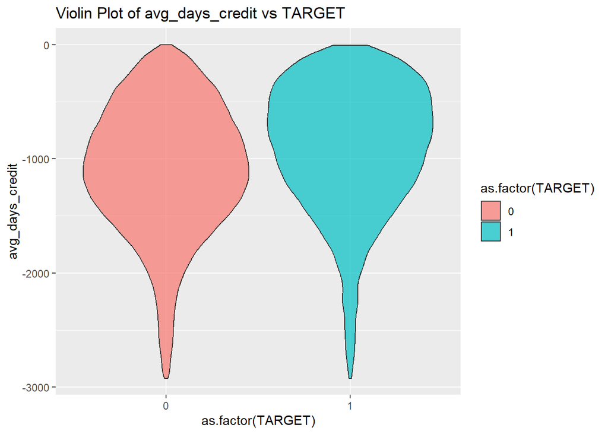

```r
## plotting the two most important variables

#avg_days_credit

# Violin Plot for avg_days_credit vs TARGET
ggplot(joined_data, aes(x=as.factor(TARGET), y=avg_days_credit, fill=as.factor(TARGET))) +
  geom_violin(alpha=0.7) +
  ggtitle("Violin Plot of avg_days_credit vs TARGET")
```

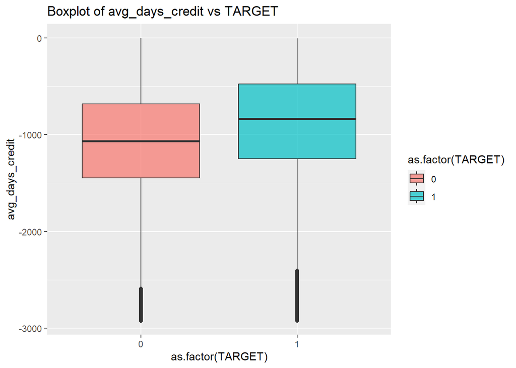

```r
# Boxplot for avg_days_credit vs TARGET
ggplot(joined_data, aes(x=as.factor(TARGET), y=avg_days_credit, fill=as.factor(TARGET))) +
  geom_boxplot(alpha=0.7) +
  ggtitle("Boxplot of avg_days_credit vs TARGET")
```

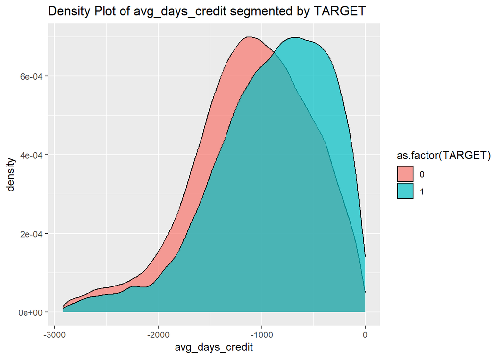

```r
# Density Plot for avg_days_credit segmented by TARGET
ggplot(joined_data, aes(x=avg_days_credit, fill=as.factor(TARGET))) +
  geom_density(alpha=0.7) +
  ggtitle("Density Plot of avg_days_credit segmented by TARGET")
```

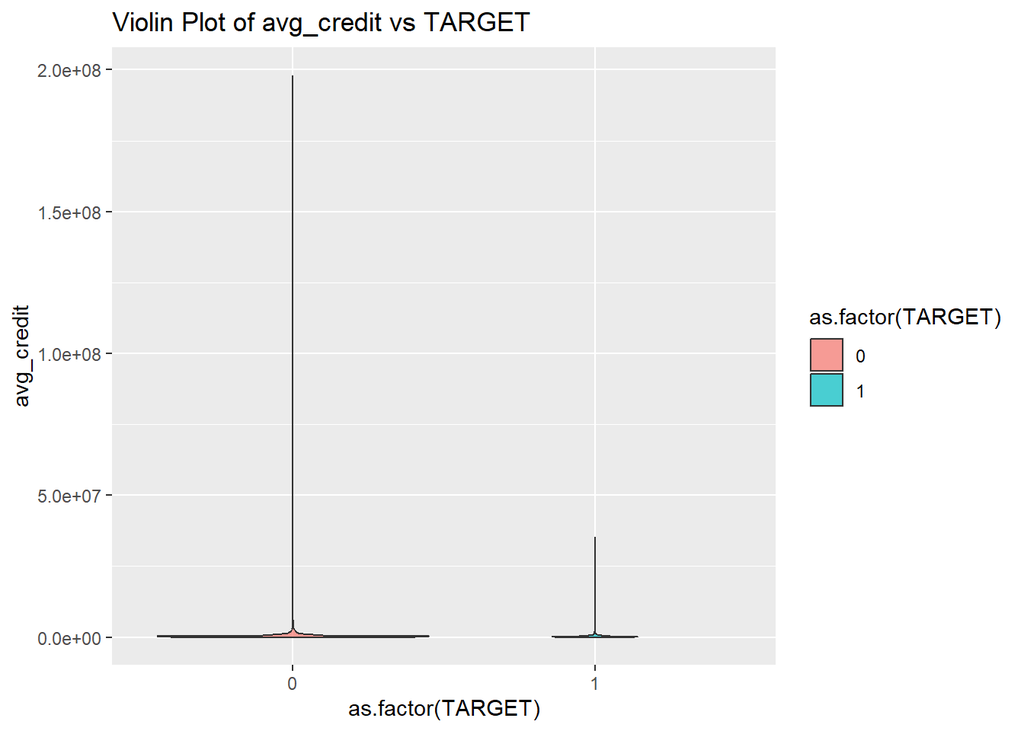

```r
## avg_credit

# Violin Plot for avg_credit vs TARGET
ggplot(joined_data, aes(x=as.factor(TARGET), y=avg_credit, fill=as.factor(TARGET))) +
  geom_violin(alpha=0.7) +
  ggtitle("Violin Plot of avg_credit vs TARGET")
```

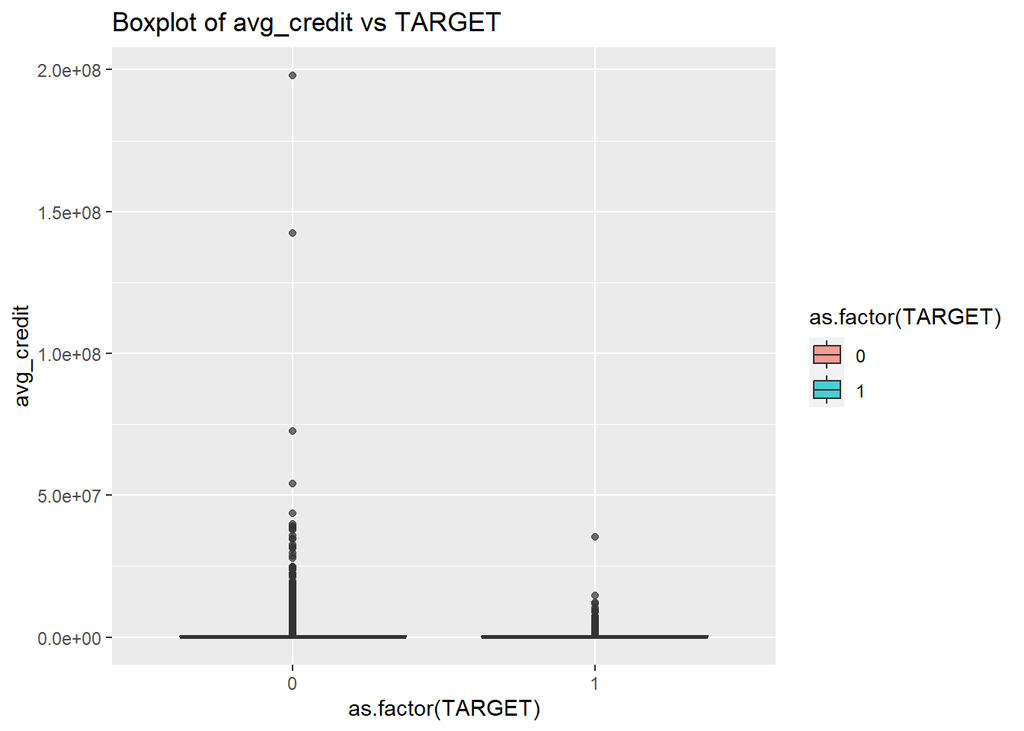

```r
# Boxplot for avg_credit vs TARGET
ggplot(joined_data, aes(x=as.factor(TARGET), y=avg_credit, fill=as.factor(TARGET))) +
  geom_boxplot(alpha=0.7) +
  ggtitle("Boxplot of avg_credit vs TARGET")
```

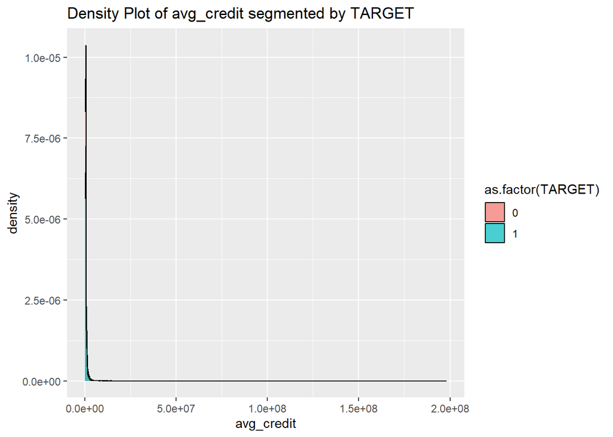

```r
# Density Plot for avg_credit segmented by TARGET
ggplot(joined_data, aes(x=avg_credit, fill=as.factor(TARGET))) +
  geom_density(alpha=0.7) +
  ggtitle("Density Plot of avg_credit segmented by TARGET")
```

## Test Set Cleaning

```r
clean_test_data <- function(test_data) {

  # Part 2: Handling Missing Values and Outliers
  # Calculate the proportion of missing values for each column
  missing_props <- map_dbl(test_data, ~mean(is.na(.)))
  # Filter out columns with more than 60% missing values
  test1 <- test_data %>% select(which(missing_props <= 0.6))

  # Factoring categorical variables
  test2 <- test1
  test2[] <- lapply(test1, function(x) if (is.character(x)) factor(x) else x)

  # Changing negative values to absolute values
  test3 <- test2 %>%
    mutate(
      DAYS_BIRTH = ifelse(DAYS_BIRTH < 0, abs(DAYS_BIRTH), DAYS_BIRTH),
      DAYS_EMPLOYED = ifelse(DAYS_EMPLOYED < 0, abs(DAYS_EMPLOYED), DAYS_EMPLOYED),
      DAYS_REGISTRATION = ifelse(DAYS_REGISTRATION < 0, abs(DAYS_REGISTRATION), DAYS_REGISTRATION),
      DAYS_ID_PUBLISH = ifelse(DAYS_ID_PUBLISH < 0, abs(DAYS_ID_PUBLISH), DAYS_ID_PUBLISH),
      DAYS_LAST_PHONE_CHANGE = ifelse(DAYS_LAST_PHONE_CHANGE < 0, abs(DAYS_LAST_PHONE_CHANGE), DAYS_LAST_PHONE_CHANGE))

  # Dealing with outliers
  test4 <- test3 %>%
    mutate(AMT_INCOME_TOTAL = ifelse(AMT_INCOME_TOTAL > quantile(AMT_INCOME_TOTAL, 0.99, na.rm = TRUE),
                                     quantile(AMT_INCOME_TOTAL, 0.99, na.rm = TRUE),
                                     AMT_INCOME_TOTAL)) %>%
    mutate(DAYS_EMPLOYED = ifelse(DAYS_EMPLOYED == 365243,
                                  median(DAYS_EMPLOYED[DAYS_EMPLOYED != 365243], na.rm = TRUE),
                                  DAYS_EMPLOYED)) %>%
    mutate(CNT_CHILDREN = ifelse(CNT_CHILDREN > 5, 5, CNT_CHILDREN)) %>%
    mutate(AMT_REQ_CREDIT_BUREAU_QRT = ifelse(AMT_REQ_CREDIT_BUREAU_QRT > quantile(AMT_REQ_CREDIT_BUREAU_QRT, 0.95, na.rm = TRUE),
                                              quantile(AMT_REQ_CREDIT_BUREAU_QRT, 0.95, na.rm = TRUE),
                                              AMT_REQ_CREDIT_BUREAU_QRT)) %>%
    mutate(REGION_POPULATION_RELATIVE = ifelse(REGION_POPULATION_RELATIVE > quantile(REGION_POPULATION_RELATIVE, 0.99, na.rm = TRUE),
                                               quantile(REGION_POPULATION_RELATIVE, 0.99, na.rm = TRUE),
                                               REGION_POPULATION_RELATIVE))

  # Part 4: Feature Engineering
  test4 <- test4 %>%
    mutate(income_credit_ratio = AMT_INCOME_TOTAL / AMT_CREDIT,
           annuity_credit_ratio = AMT_ANNUITY / AMT_CREDIT,
           age_employment_ratio = DAYS_BIRTH / DAYS_EMPLOYED)
  # Remove infinite values
  test4 <- test4[!is.infinite(test4$age_employment_ratio), ]

  # Part 5: More Cleaning and Final Preparations
  # Impute missing values
  median_cols <- c("AMT_ANNUITY", "AMT_GOODS_PRICE", "annuity_credit_ratio", "AMT_REQ_CREDIT_BUREAU_WEEK", "AMT_REQ_CREDIT_BUREAU_MON", "AMT_REQ_CREDIT_BUREAU_QRT",
"AMT_REQ_CREDIT_BUREAU_YEAR", "OBS_30_CNT_SOCIAL_CIRCLE", "DEF_30_CNT_SOCIAL_CIRCLE",
"OBS_60_CNT_SOCIAL_CIRCLE", "DEF_60_CNT_SOCIAL_CIRCLE", "DAYS_LAST_PHONE_CHANGE", "EXT_SOURCE_1", "EXT_SOURCE_2")
  mean_cols <- c("CNT_FAM_MEMBERS", "EXT_SOURCE_3")

  for (col in median_cols) {
    test4 <- test4 %>%
      mutate(!!col := ifelse(is.na(!!sym(col)), median(!!sym(col), na.rm = TRUE), !!sym(col)))
  }

  for (col in mean_cols) {
    test4 <- test4 %>%
      mutate(!!col := ifelse(is.na(!!sym(col)), mean(!!sym(col), na.rm = TRUE), !!sym(col)))
  }


  return(test4)
}

library(purrr)

test_cleaned <- clean_test_data(test_data)



# Get the names of the columns in clean8
clean8_columns <- colnames(clean8)

# Find the common columns between test_cleaned and clean8
common_columns <- intersect(colnames(test_cleaned), clean8_columns)

# Select only the common columns from test_cleaned
test_cleaned2 <- test_cleaned[, common_columns, drop = FALSE]


test_cleaned2 %>% skim() %>% kable()
```

| skim_type | skim_variable | n_missing | complete_rate | factor.ordered | factor.n_unique | factor.top_counts | numeric.mean | numeric.sd | numeric.p0 | numeric.p25 | numeric.p50 | numeric.p75 | numeric.p100 | numeric.hist |
| --- | --- | --- | --- | --- | --- | --- | --- | --- | --- | --- | --- | --- | --- | --- |
| factor | CODE_GENDER | 0 | 1 | FALSE | 2 | F: 32678, M: 16066 | NA | NA | NA | NA | NA | NA | NA | NA |
| factor | FLAG_OWN_CAR | 0 | 1 | FALSE | 2 | N: 32311, Y: 16433 | NA | NA | NA | NA | NA | NA | NA | NA |
| factor | FLAG_OWN_REALTY | 0 | 1 | FALSE | 2 | Y: 33658, N: 15086 | NA | NA | NA | NA | NA | NA | NA | NA |
| factor | NAME_TYPE_SUITE | 0 | 1 | FALSE | 8 | Una: 39727, Fam: 5881, Spo: 1448, emp: 911 | NA | NA | NA | NA | NA | NA | NA | NA |
| factor | NAME_INCOME_TYPE | 0 | 1 | FALSE | 7 | Wor: 24533, Com: 11402, Pen: 9273, Sta: 3532 | NA | NA | NA | NA | NA | NA | NA | NA |
| factor | NAME_EDUCATION_TYPE | 0 | 1 | FALSE | 5 | Sec: 33988, Hig: 12516, Inc: 1724, Low: 475 | NA | NA | NA | NA | NA | NA | NA | NA |
| factor | NAME_FAMILY_STATUS | 0 | 1 | FALSE | 5 | Mar: 32283, Sin: 7036, Civ: 4261, Sep: 2955 | NA | NA | NA | NA | NA | NA | NA | NA |
| factor | NAME_HOUSING_TYPE | 0 | 1 | FALSE | 6 | Hou: 43645, Wit: 2234, Mun: 1617, Ren: 718 | NA | NA | NA | NA | NA | NA | NA | NA |
| factor | OCCUPATION_TYPE | 0 | 1 | FALSE | 19 | emp: 15605, Lab: 8655, Sal: 5072, Cor: 4361 | NA | NA | NA | NA | NA | NA | NA | NA |
| factor | WEEKDAY_APPR_PROCESS_START | 0 | 1 | FALSE | 7 | TUE: 9751, WED: 8457, THU: 8418, MON: 8406 | NA | NA | NA | NA | NA | NA | NA | NA |
| factor | ORGANIZATION_TYPE | 0 | 1 | FALSE | 58 | Bus: 10840, XNA: 9274, Sel: 5920, Oth: 2707 | NA | NA | NA | NA | NA | NA | NA | NA |
| numeric | CNT_CHILDREN | 0 | 1 | NA | NA | NA | 3.962129e-01 | 6.987220e-01 | 0.00000e+00 | 0.000000e+00 | 0.000000e+00 | 1.000000e+00 | 5.000000e+00 | ▇▁▁▁▁ |
| numeric | AMT_INCOME_TOTAL | 0 | 1 | NA | NA | NA | 1.765226e+05 | 8.716296e+04 | 2.69415e+04 | 1.125000e+05 | 1.575000e+05 | 2.250000e+05 | 5.175000e+05 | ▅▇▃▁▁ |
| numeric | AMT_CREDIT | 0 | 1 | NA | NA | NA | 5.167404e+05 | 3.653970e+05 | 4.50000e+04 | 2.606400e+05 | 4.500000e+05 | 6.750000e+05 | 2.245500e+06 | ▇▅▁▁▁ |
| numeric | AMT_ANNUITY | 0 | 1 | NA | NA | NA | 2.942465e+04 | 1.601258e+04 | 2.29500e+03 | 1.797300e+04 | 2.619900e+04 | 3.739050e+04 | 1.805760e+05 | ▇▂▁▁▁ |
| numeric | AMT_GOODS_PRICE | 0 | 1 | NA | NA | NA | 4.626188e+05 | 3.367102e+05 | 4.50000e+04 | 2.250000e+05 | 3.960000e+05 | 6.300000e+05 | 2.245500e+06 | ▇▃▁▁▁ |
| numeric | REGION_POPULATION_RELATIVE | 0 | 1 | NA | NA | NA | 2.122560e-02 | 1.442820e-02 | 2.53000e-04 | 1.000600e-02 | 1.885000e-02 | 2.866300e-02 | 7.250800e-02 | ▇▇▃▁▁ |
| numeric | DAYS_BIRTH | 0 | 1 | NA | NA | NA | 1.606808e+04 | 4.325900e+03 | 7.33800e+03 | 1.249600e+04 | 1.578500e+04 | 1.963700e+04 | 2.519500e+04 | ▅▇▇▆▅ |
| numeric | DAYS_EMPLOYED | 0 | 1 | NA | NA | NA | 2.341324e+03 | 2.095535e+03 | 1.00000e+00 | 1.048000e+03 | 1.765000e+03 | 2.910000e+03 | 1.746300e+04 | ▇▂▁▁▁ |
| numeric | DAYS_REGISTRATION | 0 | 1 | NA | NA | NA | 4.967653e+03 | 3.552612e+03 | 0.00000e+00 | 1.901000e+03 | 4.490000e+03 | 7.459250e+03 | 2.372200e+04 | ▇▅▂▁▁ |
| numeric | DAYS_ID_PUBLISH | 0 | 1 | NA | NA | NA | 3.051713e+03 | 1.569277e+03 | 0.00000e+00 | 1.706000e+03 | 3.234000e+03 | 4.448000e+03 | 6.348000e+03 | ▅▅▅▇▂ |
| numeric | FLAG_WORK_PHONE | 0 | 1 | NA | NA | NA | 2.047021e-01 | 4.034879e-01 | 0.00000e+00 | 0.000000e+00 | 0.000000e+00 | 0.000000e+00 | 1.000000e+00 | ▇▁▁▁▂ |
| numeric | FLAG_PHONE | 0 | 1 | NA | NA | NA | 2.631298e-01 | 4.403368e-01 | 0.00000e+00 | 0.000000e+00 | 0.000000e+00 | 1.000000e+00 | 1.000000e+00 | ▇▁▁▁▃ |
| numeric | FLAG_EMAIL | 0 | 1 | NA | NA | NA | 1.626457e-01 | 3.690459e-01 | 0.00000e+00 | 0.000000e+00 | 0.000000e+00 | 0.000000e+00 | 1.000000e+00 | ▇▁▁▁▂ |
| numeric | CNT_FAM_MEMBERS | 0 | 1 | NA | NA | NA | 2.146767e+00 | 8.904229e-01 | 1.00000e+00 | 2.000000e+00 | 2.000000e+00 | 3.000000e+00 | 2.100000e+01 | ▇▁▁▁▁ |
| numeric | REGION_RATING_CLIENT | 0 | 1 | NA | NA | NA | 2.038159e+00 | 5.226940e-01 | 1.00000e+00 | 2.000000e+00 | 2.000000e+00 | 2.000000e+00 | 3.000000e+00 | ▁▁▇▁▂ |
| numeric | REGION_RATING_CLIENT_W_CITY | 0 | 1 | NA | NA | NA | 2.012596e+00 | 5.158041e-01 | -1.00000e+00 | 2.000000e+00 | 2.000000e+00 | 2.000000e+00 | 3.000000e+00 | ▁▁▂▇▂ |
| numeric | HOUR_APPR_PROCESS_START | 0 | 1 | NA | NA | NA | 1.200737e+01 | 3.278172e+00 | 0.00000e+00 | 1.000000e+01 | 1.200000e+01 | 1.400000e+01 | 2.300000e+01 | ▁▃▇▅▁ |
| numeric | REG_CITY_NOT_LIVE_CITY | 0 | 1 | NA | NA | NA | 7.746590e-02 | 2.673321e-01 | 0.00000e+00 | 0.000000e+00 | 0.000000e+00 | 0.000000e+00 | 1.000000e+00 | ▇▁▁▁▁ |
| numeric | REG_CITY_NOT_WORK_CITY | 0 | 1 | NA | NA | NA | 2.246635e-01 | 4.173648e-01 | 0.00000e+00 | 0.000000e+00 | 0.000000e+00 | 0.000000e+00 | 1.000000e+00 | ▇▁▁▁▂ |
| numeric | LIVE_CITY_NOT_WORK_CITY | 0 | 1 | NA | NA | NA | 1.742163e-01 | 3.792993e-01 | 0.00000e+00 | 0.000000e+00 | 0.000000e+00 | 0.000000e+00 | 1.000000e+00 | ▇▁▁▁▂ |
| numeric | EXT_SOURCE_1 | 0 | 1 | NA | NA | NA | 5.035350e-01 | 1.560904e-01 | 1.34579e-02 | 4.652869e-01 | 5.067713e-01 | 5.512915e-01 | 9.391445e-01 | ▁▂▇▂▁ |
| numeric | EXT_SOURCE_2 | 0 | 1 | NA | NA | NA | 5.180278e-01 | 1.812640e-01 | 8.10000e-06 | 4.080820e-01 | 5.587579e-01 | 6.584798e-01 | 8.549997e-01 | ▁▂▅▇▃ |
| numeric | EXT_SOURCE_3 | 0 | 1 | NA | NA | NA | 5.001056e-01 | 1.718246e-01 | 5.27300e-04 | 3.996756e-01 | 5.001056e-01 | 6.246147e-01 | 8.825303e-01 | ▁▃▇▅▂ |
| numeric | OBS_30_CNT_SOCIAL_CIRCLE | 0 | 1 | NA | NA | NA | 1.446783e+00 | 3.607153e+00 | 0.00000e+00 | 0.000000e+00 | 0.000000e+00 | 2.000000e+00 | 3.540000e+02 | ▇▁▁▁▁ |
| numeric | DEF_30_CNT_SOCIAL_CIRCLE | 0 | 1 | NA | NA | NA | 1.435664e-01 | 5.142717e-01 | 0.00000e+00 | 0.000000e+00 | 0.000000e+00 | 0.000000e+00 | 3.400000e+01 | ▇▁▁▁▁ |
| numeric | OBS_60_CNT_SOCIAL_CIRCLE | 0 | 1 | NA | NA | NA | 1.434884e+00 | 3.579231e+00 | 0.00000e+00 | 0.000000e+00 | 0.000000e+00 | 2.000000e+00 | 3.510000e+02 | ▇▁▁▁▁ |
| numeric | DEF_60_CNT_SOCIAL_CIRCLE | 0 | 1 | NA | NA | NA | 1.010791e-01 | 4.036786e-01 | 0.00000e+00 | 0.000000e+00 | 0.000000e+00 | 0.000000e+00 | 2.400000e+01 | ▇▁▁▁▁ |
| numeric | DAYS_LAST_PHONE_CHANGE | 0 | 1 | NA | NA | NA | 1.077766e+03 | 8.789207e+02 | 0.00000e+00 | 3.630000e+02 | 8.630000e+02 | 1.766250e+03 | 4.361000e+03 | ▇▃▃▁▁ |
| numeric | FLAG_DOCUMENT_3 | 0 | 1 | NA | NA | NA | 7.866199e-01 | 4.096980e-01 | 0.00000e+00 | 1.000000e+00 | 1.000000e+00 | 1.000000e+00 | 1.000000e+00 | ▂▁▁▁▇ |
| numeric | FLAG_DOCUMENT_8 | 0 | 1 | NA | NA | NA | 8.846220e-02 | 2.839688e-01 | 0.00000e+00 | 0.000000e+00 | 0.000000e+00 | 0.000000e+00 | 1.000000e+00 | ▇▁▁▁▁ |
| numeric | AMT_REQ_CREDIT_BUREAU_WEEK | 0 | 1 | NA | NA | NA | 2.441300e-03 | 5.058170e-02 | 0.00000e+00 | 0.000000e+00 | 0.000000e+00 | 0.000000e+00 | 2.000000e+00 | ▇▁▁▁▁ |
| numeric | AMT_REQ_CREDIT_BUREAU_MON | 0 | 1 | NA | NA | NA | 8.144600e-03 | 1.038581e-01 | 0.00000e+00 | 0.000000e+00 | 0.000000e+00 | 0.000000e+00 | 6.000000e+00 | ▇▁▁▁▁ |
| numeric | AMT_REQ_CREDIT_BUREAU_QRT | 0 | 1 | NA | NA | NA | 4.656778e-01 | 6.285081e-01 | 0.00000e+00 | 0.000000e+00 | 0.000000e+00 | 1.000000e+00 | 2.000000e+00 | ▇▁▅▁▁ |
| numeric | AMT_REQ_CREDIT_BUREAU_YEAR | 0 | 1 | NA | NA | NA | 1.985783e+00 | 1.721001e+00 | 0.00000e+00 | 1.000000e+00 | 2.000000e+00 | 3.000000e+00 | 1.700000e+01 | ▇▂▁▁▁ |
| numeric | income_credit_ratio | 0 | 1 | NA | NA | NA | 4.866711e-01 | 3.992188e-01 | 3.28461e-02 | 2.481636e-01 | 3.750000e-01 | 5.882353e-01 | 7.200000e+00 | ▇▁▁▁▁ |
| numeric | annuity_credit_ratio | 0 | 1 | NA | NA | NA | 6.662140e-02 | 2.455350e-02 | 3.10373e-02 | 4.854190e-02 | 6.143600e-02 | 7.944230e-02 | 1.244296e-01 | ▆▇▅▃▂ |
| numeric | age_employment_ratio | 0 | 1 | NA | NA | NA | 1.540564e+01 | 6.254875e+01 | 1.38666e+00 | 5.012201e+00 | 1.025127e+01 | 1.372810e+01 | 1.227200e+04 | ▇▁▁▁▁ |

# III. Final Modeling

For our final predictive model, we selected XGBoost (eXtreme Gradient Boosting) due to its well-documented efficiency, especially in handling complex datasets like ours. One of the key factors that influenced this choice was the algorithm’s built-in regularization capabilities, which help prevent overfitting—an essential consideration given our dataset’s high dimensionality and class imbalance.

In the initial phase of model training, we partitioned our cleaned dataset into an 85% training subset and a 15% validation subset. This allowed us to train our model on a representative sample of the data while retaining a separate portion for model evaluation, thereby avoiding the risk of overfitting, and ensuring that our model’s performance metrics would generalize well to unseen data.

We then converted our training and testing datasets into an optimized matrix format that XGBoost utilizes, which enhances the model training efficiency. With the data prepared, we embarked on the hyperparameter tuning process. We experimented with various configurations of learning rates, tree complexities (depths), and subsampling rates. Additionally, the scale_pos_weight parameter was critical in calibrating the model to address the imbalance in our target variable, ensuring that the minority class was appropriately weighted during learning.

In summary, our modeling journey with XGBoost was characterized by a careful balance between model complexity, performance, and practical constraints, leading to a final model that we believe capably captures the underlying patterns in the data while being computationally feasible.

## XGBOOST @ 20 Rounds

```r
# 1. Installing and loading necessary libraries
if (!requireNamespace("xgboost", quietly = TRUE)) install.packages("xgboost")
if (!requireNamespace("caret", quietly = TRUE)) install.packages("caret")
library(xgboost)
library(caret)


# Preparing the data for training and testing
set.seed(42)

labels <- clean8$TARGET
data <- clean8 %>% select(-TARGET)

# Splitting the data into training (80%) and validation (20%) sets
index <- createDataPartition(labels, p = 0.85, list = FALSE)
train_data <- data[index, ]
train_labels <- labels[index]
test_data <- data[-index, ]
test_labels <- labels[-index]

# Converting data to matrix
train_matrix <- xgb.DMatrix(data = model.matrix(~. - 1, data = train_data), label = train_labels)
test_matrix <- xgb.DMatrix(data = model.matrix(~. - 1, data = test_data), label = test_labels)

# Training the xgboost model
params <- list(
  objective = "binary:logistic",
  eta = 0.1,
  max_depth = 6,
  nthread = 3,
  eval_metric = "logloss"
)



p <- list(objective = "binary:logistic"
         , booster = "gbtree"
         , eval_metric = "logloss"
         , nthread = 6
         , eta = 0.01
         , max_depth = 12
         , min_child_weight = 25
         , subsample = 0.75
         , scale_pos_weight = 2
         , colsample_bytree = 0.75
)


model <- xgboost(
  data = train_matrix,
  params = p,
  nrounds = 20,
  gamma = 0.009,
)
# Making predictions on the test set
pred_probs <- predict(model, newdata = test_matrix)
pred_labels <- as.numeric(pred_probs > 0.50)  # Convert to 0 and 1 based on threshold

# Calculating the accuracy of the model on the test set
accuracy <- sum(pred_labels == test_labels) / length(test_labels)
print(accuracy)
```

```
## [1] 0.9202185
```

```r
cm <- confusionMatrix(as.factor(pred_labels), as.factor(test_labels))
print(cm)
```

```
## Confusion Matrix and Statistics
##
##           Reference
## Prediction     0     1
##          0 42345  3589
##          1    91   101
##
##                Accuracy : 0.9202
##                  95% CI : (0.9177, 0.9227)
##     No Information Rate : 0.92
##     P-Value [Acc > NIR] : 0.4362
##
##                   Kappa : 0.0445
##
##  Mcnemar's Test P-Value : <2e-16
##
##             Sensitivity : 0.99786
##             Specificity : 0.02737
##          Pos Pred Value : 0.92187
##          Neg Pred Value : 0.52604
##              Prevalence : 0.92000
##          Detection Rate : 0.91803
##    Detection Prevalence : 0.99584
##       Balanced Accuracy : 0.51261
##
##        'Positive' Class : 0
##
```

```r
roc_result <- roc(test_labels, pred_probs)
auc(roc_result)
```

```
## Area under the curve: 0.7483
```

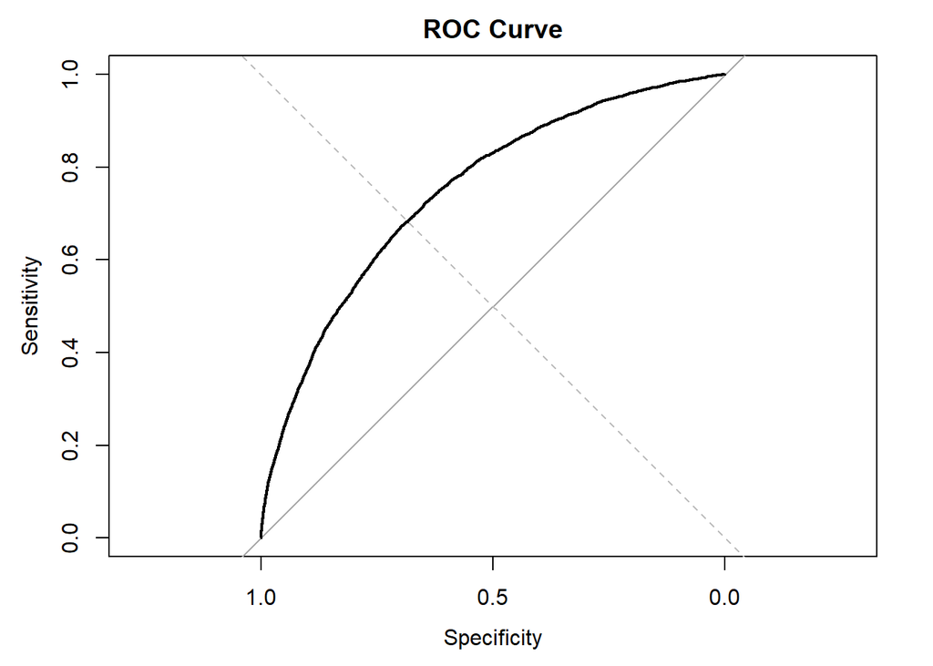

```r
plot(roc_result, main="ROC Curve")
abline(a=0, b=1, lty=2, col="gray")
```

## Submission Prep For Kaggle

```r
# unique factors

# Getting the factor variables
factor_vars <- sapply(train_data, is.factor)

# Getting the unique levels of factor variables in the training data
unique_levels <- lapply(train_data[factor_vars], function(x) unique(levels(x)))

# Setting the levels of factor variables in the test data to be the same as in the training data
test_cleaned2[factor_vars] <- Map(function(x, y) factor(x, levels = y), test_cleaned2[factor_vars], unique_levels)

# create the model matrices
model_matrix_train <- model.matrix(~. - 1, data = clean8)
model_matrix_test <- model.matrix(~. - 1, data = test_cleaned2)

# Check if the column names are the same
all(colnames(model_matrix_train) == colnames(model_matrix_test))
```

```
## [1] FALSE
```

```r
## for submit

#pred_probs <- predict(model, newdata = model_matrix_test)

#ids <- test_data$SK_ID_CURR

#submission <- data.frame(SK_ID_CURR = ids, TARGET = pred_probs)

#write_csv(submission, "submission_file_5000.csv")
```

## Kaggle Submission

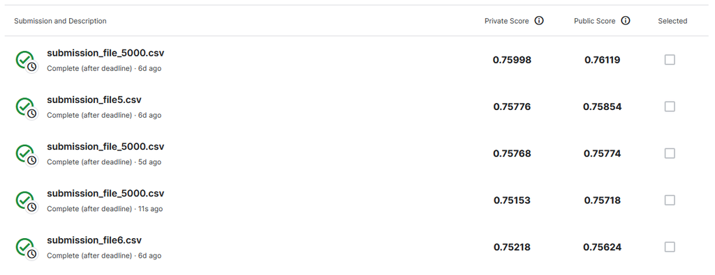

# IV. Conclusions & Next Steps

## Balancing Risk and Inclusion

Our team has developed a predictive model that estimates the likelihood of individuals defaulting on loans. While this model effectively narrows down the risk pool, it doesn’t rule out the possibility of default for any particular individual. Recognizing this, we aim to initiate a strategic discussion on setting appropriate thresholds for loan approval criteria. These thresholds can be adjusted dynamically in response to the prevailing economic climate, giving management the flexibility to tighten or relax loan eligibility as needed.

In practice, we applied two models concurrently to illustrate the impact of changing the default prediction threshold. By increasing the threshold, we deliberately accept more false negatives, which directly influences the model’s risk sensitivity. This adjustment allows us to explore the equilibrium between extending credit to a broader spectrum of applicants, including those with minimal banking history, and upholding strict lending standards to safeguard against default risks.

A higher threshold in the model means default is predicted less often, which can be beneficial for including customers who may have limited financial history but also increases the lender’s exposure to potential defaults. By expanding credit offerings to this underrepresented group, we not only grow our customer base but also contribute to greater financial inclusiveness. Our analysis aims to provide management with insight into how threshold settings affect loan accessibility and risk, empowering informed decision-making that aligns with the company’s risk appetite and market growth objectives.

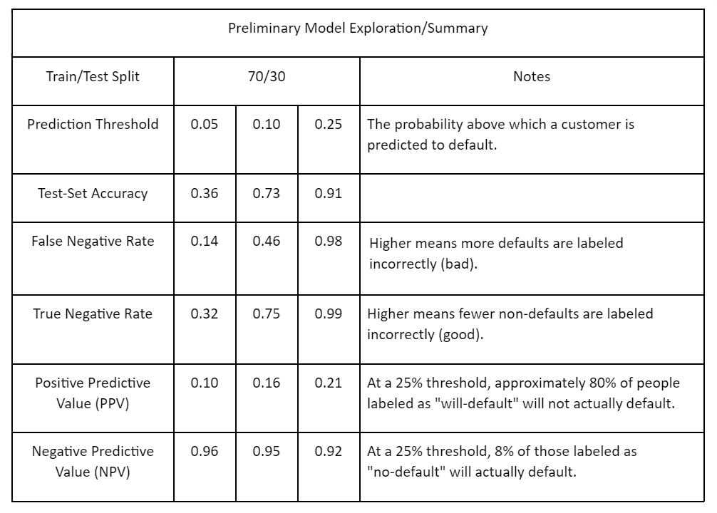

Credit Evaluation

Our evaluation revealed consistent model performance across various train/test splits, confirming stability in our metrics. Therefore, we have presented results from the conventional 70/30 split for simplicity.

The table above shows the compromises that must be made when defining the acceptance criteria for a default/non-default ruling. Ideally, everyone who is not going to default can get a loan. This metric is captured by the True Negative Rate, which improves as the Prediction Threshold increases. In an optimal solution, no one who is going to default is mistakenly offered a loan either. This is the False Negative Rate, which worsens as the prediction threshold increases. These metrics are relatively intangible, so the results can be interpreted using the Positive and Negative Predictive Values, which show how likely a provided result is to be correct. We can see that these two values vary in opposite directions as the Prediction Threshold increases. The final decision by Home Credit will have to select a threshold that balances excluding “no-default” customers from the marketplace (PPV) while allowing some customers who will default into the marketplace (NPV).

Looking ahead, the strategic use of these modeling insights could enable Home Credit to fine-tune their credit scoring algorithms. By considering the trade-offs between market expansion and risk management, we can adapt their models to better serve varied customer segments. Including non-conventional data in risk assessment could provide a more accurate financial profile for underbanked individuals. Furthermore, the results support the development of customized financial products that balance risk and access to credit, thereby contributing to broader economic participation among traditionally underserved populations.

## Conclusion

Our next steps include determining the amount of risk Home Credit management is willing to accept in losses due to default, employ this model and put it into production in a test environment with new customers, determine sales goals and quotas for periods of time and geographic locations, and lastly and most importantly create a new standard for data collection such that our employees capture all of the data that is required to present the best case for a customer to apply for and obtain a loan from us.